# Course Notes on HCI Experiments

## Interaction plot of Error_Rate

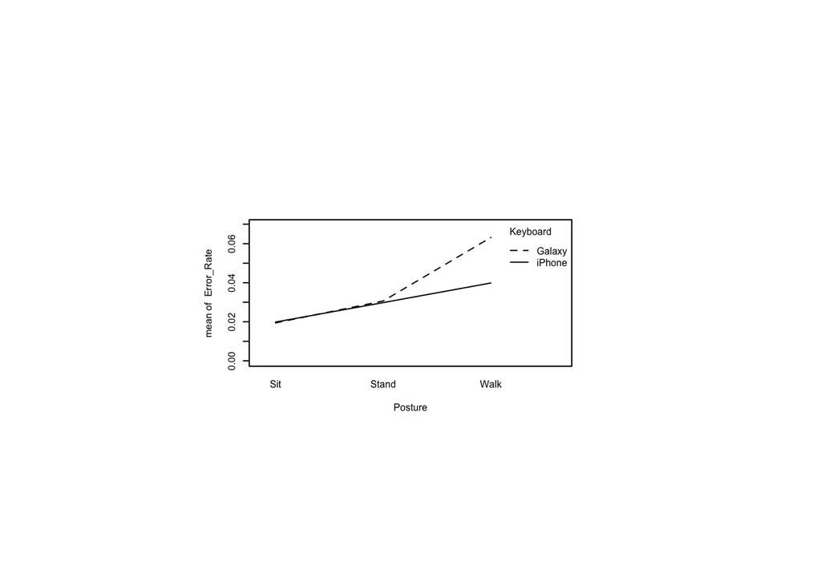

```r
par(pin=c(2.75,1.25),cex=0.5)
with(mbltxt,
     interaction.plot(Posture, Keyboard, Error_Rate,
                      ylim=c(0, max(mbltxt$Error_Rate))))
```

## Aligned Rank Transform on Error_Rate

```r
pacman::p_load(ARTool) # for art, artlm
m <- art(Error_Rate ~ Keyboard * Posture + (1|Subject), data=mbltxt) # uses LMM
anova(m) # report anova
```

```
boundary (singular) fit: see help('isSingular')
```

```
Analysis of Variance of Aligned Rank Transformed Data

Table Type: Analysis of Deviance Table (Type III Wald F tests with Kenward-Roger df)
Model: Mixed Effects (lmer)
Response: art(Error_Rate)

                         F Df Df.res     Pr(>F)
1 Keyboard          89.450  1     22 3.2959e-09 ***
2 Posture          274.704  2     44 < 2.22e-16 ***
3 Keyboard:Posture  78.545  2     44 3.0298e-15 ***
---
Signif. codes:   0 '***' 0.001 '**' 0.01 '*' 0.05 '.' 0.1 ' ' 1
```

## Examine the normality assumption

```r
par(pin=c(2.75,1.25),cex=0.5)
shapiro.test(residuals(m)) # normality?
```

```
    Shapiro-Wilk normality test

data:  residuals(m)
W = 0.98453, p-value = 0.5227
```

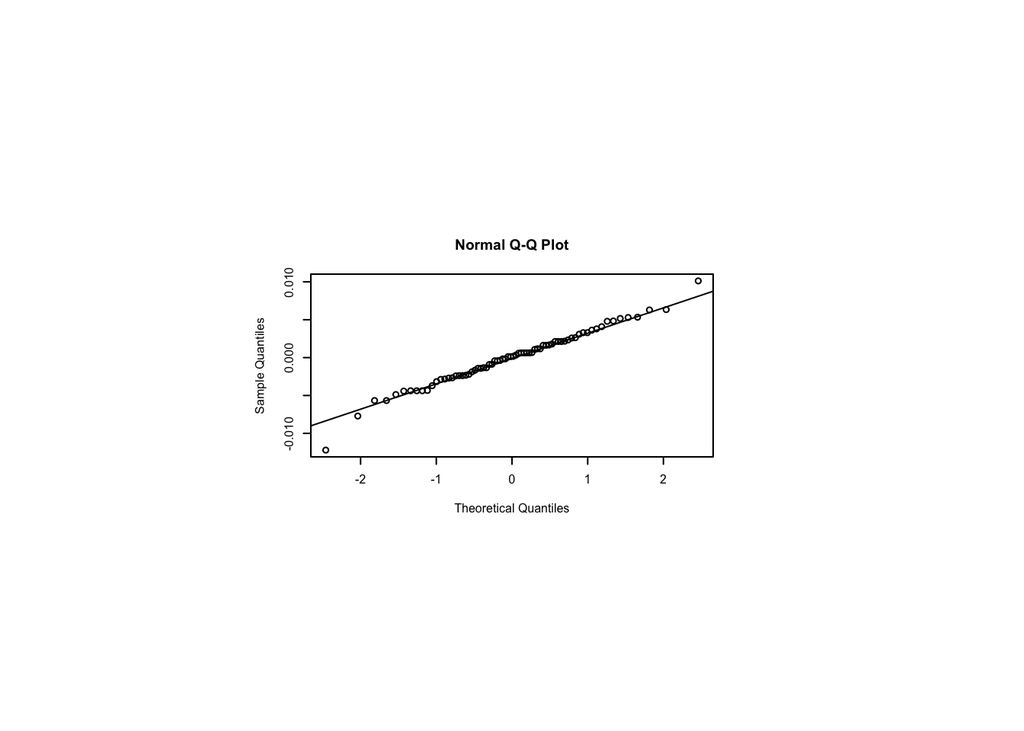

```r
qqnorm(residuals(m)); qqline(residuals(m)) # seems to conform
```

## Interaction plot

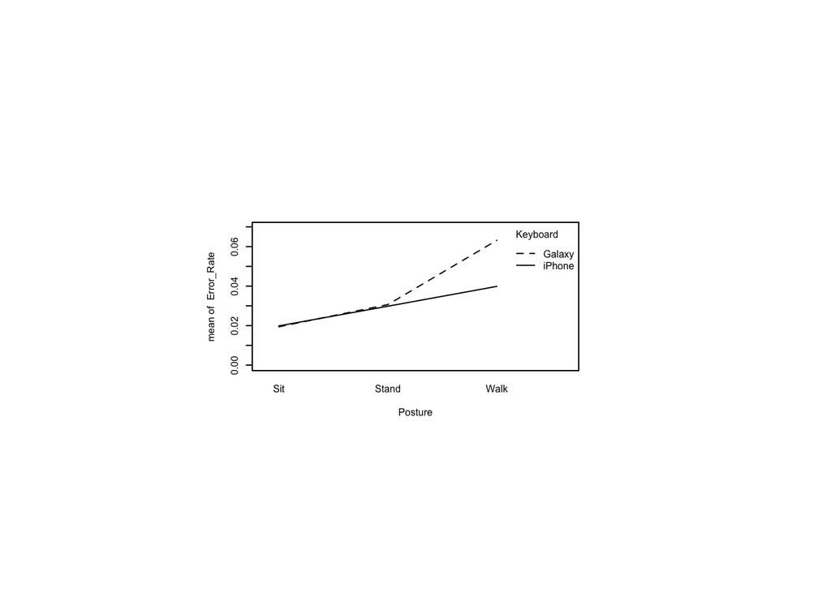

```r
par(pin=c(2.75,1.25),cex=0.5)
with(mbltxt,
     interaction.plot(Posture, Keyboard, Error_Rate,
              ylim=c(0, max(mbltxt$Error_Rate)))) # for convenience
```

## Conduct post hoc pairwise comparisons within each factor

```r
#. pacman::p_load(emmeans) # instead of lsmeans
#. for backward compatibility, emmeans provides an lsmeans() function
lsmeans(artlm(m, "Keyboard"), pairwise ~ Keyboard)
```

```
NOTE: Results may be misleading due to involvement in interactions
```

```
$lsmeans
 Keyboard lsmean   SE df lower.CL upper.CL
 Galaxy     52.3 2.36 22     47.4     57.2
 iPhone     20.7 2.36 22     15.8     25.6

Results are averaged over the levels of: Posture
Degrees-of-freedom method: kenward-roger
Confidence level used: 0.95

$contrasts
 contrast        estimate   SE df t.ratio p.value
 Galaxy - iPhone     31.6 3.34 22   9.458 <0.0001

Results are averaged over the levels of: Posture
Degrees-of-freedom method: kenward-roger
```

```r
lsmeans(artlm(m, "Posture"), pairwise ~ Posture)
```

```
NOTE: Results may be misleading due to involvement in interactions
```

```
$lsmeans
 Posture lsmean   SE   df lower.CL upper.CL
 Sit       12.5 1.47 65.9     9.57     15.4
 Stand     36.5 1.47 65.9    33.57     39.4
 Walk      60.5 1.47 65.9    57.57     63.4

Results are averaged over the levels of: Keyboard
Degrees-of-freedom method: kenward-roger
Confidence level used: 0.95

$contrasts
 contrast     estimate   SE df t.ratio p.value
 Sit - Stand       -24 2.05 44 -11.720 <0.0001
 Sit - Walk        -48 2.05 44 -23.439 <0.0001
 Stand - Walk      -24 2.05 44 -11.720 <0.0001

Results are averaged over the levels of: Keyboard
Degrees-of-freedom method: kenward-roger
P value adjustment: tukey method for comparing a family of 3 estimates
```

```r
#. Warning: don't do the following in ART!
#lsmeans(artlm(m, "Keyboard : Posture"), pairwise ~ Keyboard : Posture)
```

The above contrast-testing method is invalid for cross-factor pairwise comparisons in ART. and you can’t just grab aligned-ranks for manual $t$-tests. instead, use `testInteractions()` from the `phia` package to perform “interaction contrasts.” See `vignette("art-contrasts")`.

```r
pacman::p_load(phia)
testInteractions(artlm(m, "Keyboard:Posture"),
                 pairwise=c("Keyboard", "Posture"), adjustment="holm")
```

```
boundary (singular) fit: see help('isSingular')
```

```
Chisq Test:
P-value adjustment method: holm
                             Value     SE Df    Chisq Pr(>Chisq)
Galaxy-iPhone :  Sit-Stand  -5.083 6.8028  1   0.5584     0.4549
Galaxy-iPhone :   Sit-Walk -76.250 6.8028  1 125.6340     <2e-16 ***
Galaxy-iPhone : Stand-Walk -71.167 6.8028  1 109.4412     <2e-16 ***
---
Signif. codes:  0 '***' 0.001 '**' 0.01 '*' 0.05 '.' 0.1 ' ' 1
```

In the output, A-B : C-D is interpreted as a difference-of-differences, i.e., the difference between (A-B | C) and (A-B | D). In words, is the difference between A and B significantly different in condition C from condition D?

# Experiments with interaction effects

This section reports on three experiments with possible interaction effects: Avatars, Notes, and Social media value. To work through the questions, you need the three `csv` files containing the data: `avatars.csv`, `notes.csv`, and `socialvalue.csv`.

These experiments may be between-subjects, within-subjects, or mixed. To be a mixed factorial design, there would have to be at least two independent variables and at least one within-subjects factor and at least one between-subjects factor.

## Sentiments about Avatars among males and females (Interaction effects)

Thirty males and thirty females were shown an avatar that was either male or female and asked to write a story about that avatar. The number of positive sentiments in the story were summed. What kind of experimental design is this? [Answer: It is a $2\times 2$ between-subjects design with factors for Sex (M, F) and Avatar (M, F).]

```r
avatars <- read_csv("avatars.csv")
avatars$Subject <- factor(avatars$Subject)
summary(avatars)
```

```
    Subject          Sex           Avatar     Positives
 1      : 1   Length   :60   Length   :60   Min.   : 32.0
 2      : 1   N.unique : 2   N.unique : 2   1st Qu.: 65.0
 3      : 1   N.blank  : 0   N.blank  : 0   Median : 84.0
 4      : 1   Min.nchar: 4   Min.nchar: 4   Mean   : 85.1
 5      : 1   Max.nchar: 6   Max.nchar: 6   3rd Qu.:104.2
 6      : 1                                 Max.   :149.0
 (Other):54
```

What’s the average number of positive sentiments for the most positive combination of Sex and Avatar?

```r
plyr::ddply(avatars,~Sex*Avatar,summarize,
      Pos.mean=mean(Positives),
      Pos.sd=sd(Positives))
```

```
     Sex Avatar  Pos.mean   Pos.sd
1 Female Female  63.13333 17.48414
2 Female   Male  85.20000 25.31008
3   Male Female 100.73333 18.72152
4   Male   Male  91.33333 19.66384
```

Create an interaction plot with Sex on the X-Axis and Avatar as the traces. Do the lines cross? Do the same for reversed axes.

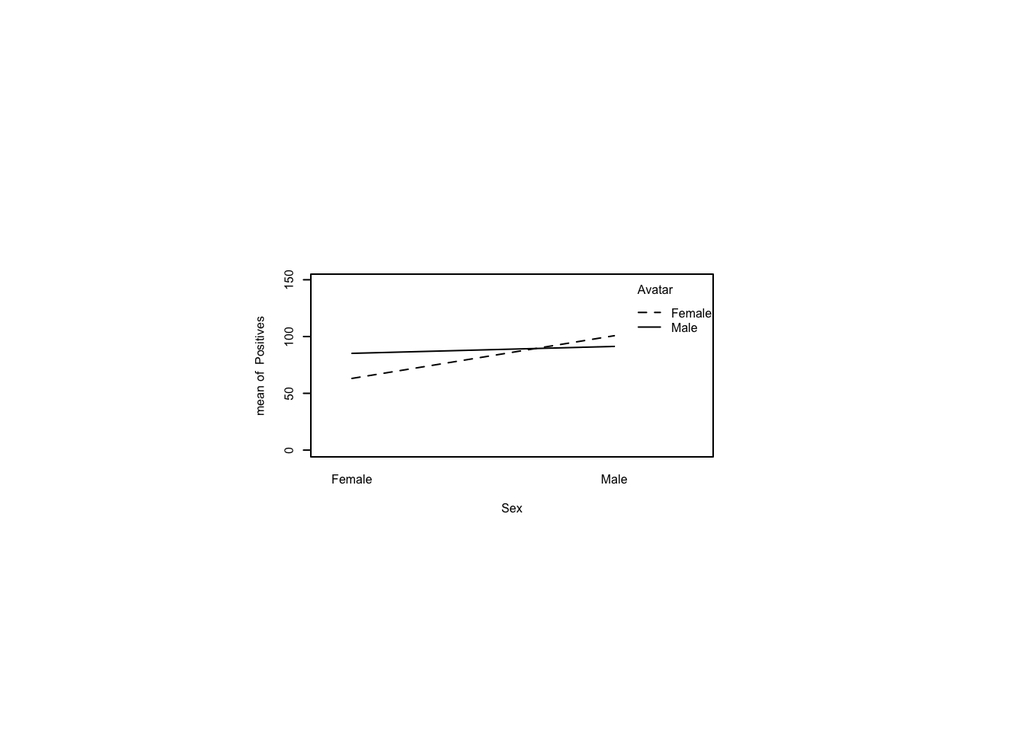

```r
par(pin=c(2.75,1.25),cex=0.5)
with(avatars,interaction.plot(Sex,Avatar,Positives,
                  ylim=c(0,max(avatars$Positives))))
```

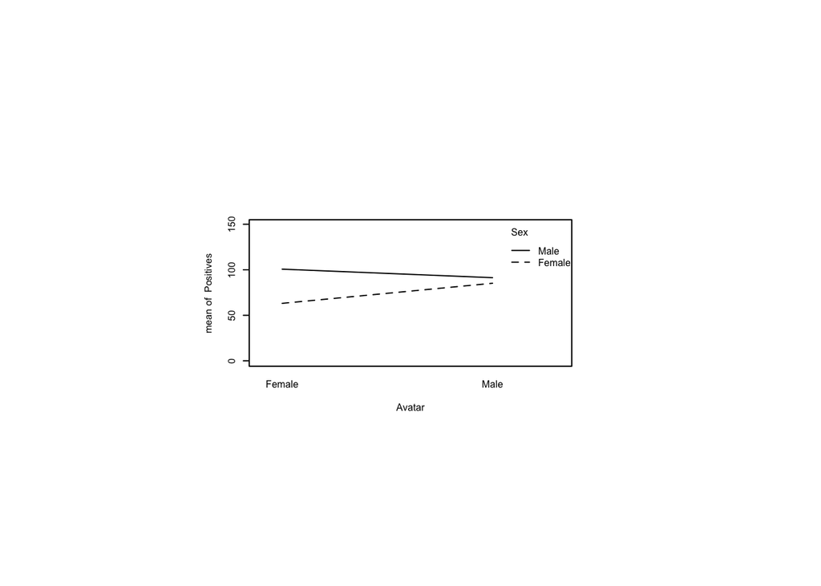

```r
with(avatars,interaction.plot(Avatar,Sex,Positives,
                  ylim=c(0,max(avatars$Positives))))
```

Conduct a factorial ANOVA on Positives by Sex and Avatar and report the largest $F$-statistic. Report which effects are significant.

```r
m<-ezANOVA(dv=Positives,between=c(Sex,Avatar),
       wid=Subject,data=avatars)
```

```
Coefficient covariances computed by hccm()
```

```r
m$ANOVA
```

```
      Effect DFn DFd         F            p p<.05        ges
1        Sex   1  56 17.041756 0.0001228287     * 0.23331526
2     Avatar   1  56  1.429598 0.2368686270       0.02489305
3 Sex:Avatar   1  56  8.822480 0.0043757511     * 0.13610216
```

Conduct planned pairwise comparisons using independent-samples $t$-tests. Ask whether females produced different numbers of positive sentiments for male vs female avatars. Then ask whether males did the same. Assume equal variances and use Holm’s sequential Bonferroni procedure to correct for multiple comparisons.

```r
f<-t.test(avatars[avatars$Sex=="Female" & avatars$Avatar=="Male",]$Positives,
      avatars[avatars$Sex=="Female" & avatars$Avatar=="Female",]$Positives,
      var.equal=TRUE)
f
```

```
    Two Sample t-test

data:  avatars[avatars$Sex == "Female" & avatars$Avatar == "Male", ]$Positives and avatars[avatars$Sex == "Female" & avatars$Avatar == "Female", ]$Positives
t = 2.7782, df = 28, p-value = 0.009647
alternative hypothesis: true difference in means is not equal to 0
95 percent confidence interval:
  5.796801 38.336533
sample estimates:
mean of x mean of y
 85.20000  63.13333
```

```r
m<-t.test(avatars[avatars$Sex=="Male" & avatars$Avatar=="Male",]$Positives,
      avatars[avatars$Sex=="Male" & avatars$Avatar=="Female",]$Positives,
      var.equal=TRUE)
m
```

```
    Two Sample t-test

data:  avatars[avatars$Sex == "Male" & avatars$Avatar == "Male", ]$Positives and avatars[avatars$Sex == "Male" & avatars$Avatar == "Female", ]$Positives
t = -1.3409, df = 28, p-value = 0.1907
alternative hypothesis: true difference in means is not equal to 0
95 percent confidence interval:
 -23.759922   4.959922
sample estimates:
mean of x mean of y
 91.33333 100.73333
```

```r
p.adjust(c(f$p.value,m$p.value),method="holm")
```

```
[1] 0.01929438 0.19073468
```

## Writing notes with builtin or addon apps on two phones (mixed factorial design)

The `notes.csv` file describes a study in which iPhone and Android owners used a built-in note-taking app then a third-party note-taking app or vice versa. What kind of experimental design is this? (Answer: A $2 \times 2$ mixed factorial design with a between-subjects factor for Phone (iPhone, Android) and a within-subjects factor for Notes (Built-in, Add-on).)

```r
notes<-read_csv("notes.csv")
notes$Subject<-factor(notes$Subject)
notes$Order<-factor(notes$Order)
summary(notes)
```

```
    Subject         Phone          Notes    Order      Words
 1      : 2   Length   :40   Length   :40   1:20   Min.   :259.0
 2      : 2   N.unique : 2   N.unique : 2   2:20   1st Qu.:421.8
 3      : 2   N.blank  : 0   N.blank  : 0          Median :457.0
 4      : 2   Min.nchar: 6   Min.nchar: 6          Mean   :459.2
 5      : 2   Max.nchar: 7   Max.nchar: 8          3rd Qu.:518.5
 6      : 2                                        Max.   :598.0
 (Other):28
```

What’s the average number of words recorded for the most heavily used combination of Phone and Notes?

```r
plyr::ddply(notes, ~Phone*Notes,summarize,
         Words.mean=mean(Words),Words.sd=sd(Words))
```

```
    Phone    Notes Words.mean Words.sd
1 Android   Add-on      388.1 42.38828
2 Android Built-in      410.9 77.49043
3  iPhone   Add-on      504.2 47.29529
4  iPhone Built-in      533.7 48.04176
```

Create an interaction plot with Phone on the X-Axis and Notes as the traces. Do the lines cross? Do the same for reversed axes.

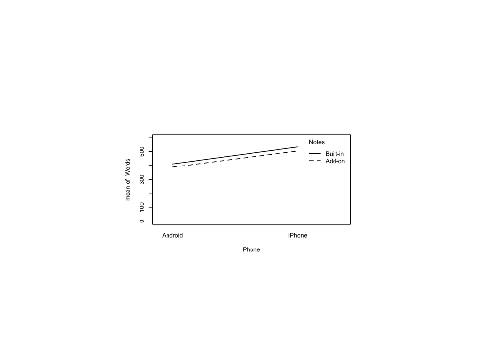

```r
par(pin=c(2.75,1.25),cex=0.5)
with(notes,interaction.plot(Phone,Notes,Words,
                ylim=c(0,max(notes$Words))))
```

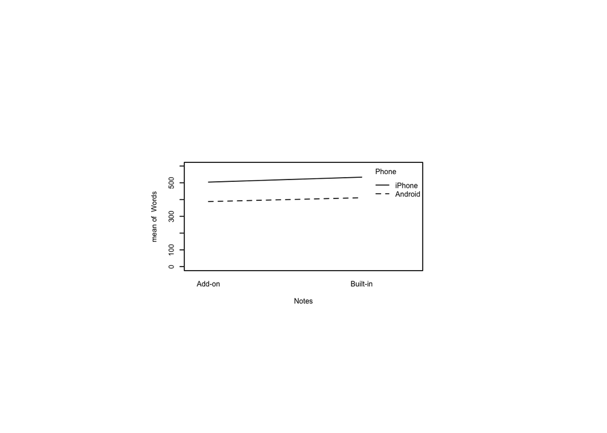

```r
with(notes,interaction.plot(Notes,Phone,Words,
                ylim=c(0,max(notes$Words))))
```

Test for an order effect in the presentation of order of the Notes factor. Report the $p$-value.

```r
m<-ezANOVA(dv=Words,between=Phone,within=Order,wid=Subject,data=notes)
m$ANOVA
```

```
       Effect DFn DFd          F            p p<.05        ges
2       Phone   1  18 43.5625695 3.375888e-06     * 0.56875437
3       Order   1  18  0.5486763 4.684126e-01       0.01368098
4 Phone:Order   1  18  3.0643695 9.705122e-02       0.07189858
```

Conduct a factorial ANOVA on Words by Phone and Notes. Report the largest $F$-statistic.

```r
m<-ezANOVA(dv=Words,between=Phone,within=Notes,wid=Subject,data=notes)
m$ANOVA
```

```
       Effect DFn DFd           F            p p<.05         ges
2       Phone   1  18 43.56256949 3.375888e-06     * 0.562185697
3       Notes   1  18  2.35976941 1.418921e-01       0.057972811
4 Phone:Notes   1  18  0.03872717 8.461951e-01       0.001008948
```

Conduct paired-samples $t$-tests to answer two questions. First, did iPhone user enter different numbers of words using the built-in notes app versus the add-on notes app? Second, same for Android. Assume equal variances and use Holm’s sequential Bonferroni procedure to correct for multiple comparisons. Report the lowest adjusted $p$-value.

```r
notes.wide<-dcast(notes,Subject+Phone~Notes,value.var="Words")
head(notes.wide)
```

```
  Subject   Phone Add-on Built-in
1       1  iPhone    464      561
2       2 Android    433      428
3       3  iPhone    598      586
4       4 Android    347      448
5       5  iPhone    478      543
6       6 Android    365      445
```

```r
i<-t.test(notes.wide[notes.wide$Phone=="iPhone",]$'Add-on',
      notes.wide[notes.wide$Phone=="iPhone",]$'Built-in',
      paired=TRUE,var.equal=TRUE)
i
```

```
    Paired t-test

data:  notes.wide[notes.wide$Phone == "iPhone", ]$"Add-on" and notes.wide[notes.wide$Phone == "iPhone", ]$"Built-in"
t = -1.8456, df = 9, p-value = 0.09804
alternative hypothesis: true mean difference is not equal to 0
95 percent confidence interval:
 -65.658758   6.658758
sample estimates:
mean difference
          -29.5
```

```r
a<-t.test(notes.wide[notes.wide$Phone=="Android",]$'Add-on',
      notes.wide[notes.wide$Phone=="Android",]$'Built-in',
      paired=TRUE,var.equal=TRUE)
a
```

```
    Paired t-test

data:  notes.wide[notes.wide$Phone == "Android", ]$"Add-on" and notes.wide[notes.wide$Phone == "Android", ]$"Built-in"
t = -0.75847, df = 9, p-value = 0.4676
alternative hypothesis: true mean difference is not equal to 0
95 percent confidence interval:
 -90.80181  45.20181
sample estimates:
mean difference
          -22.8
```

```r
p.adjust(c(i$p.value,a$p.value),method="holm")
```

```
[1] 0.1960779 0.4675674
```

## Social media value judged by people after watching clips (two-by-two within subject design)

The file socialvalue.csv describes a study of people viewing a pos or neg film clip then going onto social media and judging the value of the first 100 posts they see. The number of valued posts was recorded. What kind of experimental design is this? [Answer: A $2\times 2$ within-subject design with factors for Clip (positive, negative) and Social (Facebook, Twitter).]

```r
sv<-read_csv("socialvalue.csv")
sv$Subject<-factor(sv$Subject)
sv$Clip<-factor(sv$Clip)
sv$Social<-factor(sv$Social)
sv$ClipOrder<-factor(sv$ClipOrder)
sv$SocialOrder<-factor(sv$SocialOrder)
summary(sv)
```

```
    Subject         Clip    ClipOrder      Social   SocialOrder     Valued
 1      : 4   negative:32   1:32      Facebook:32   1:32        Min.   :13.0
 2      : 4   positive:32   2:32      Twitter :32   2:32        1st Qu.:52.0
 3      : 4                                                     Median :56.0
 4      : 4                                                     Mean   :57.3
 5      : 4                                                     3rd Qu.:67.0
 6      : 4                                                     Max.   :95.0
 (Other):40
```

What’s the average number of valued posts for the most valued combination of Clip and Social?

```r
plyr::ddply(sv, ~Clip*Social,summarize, Valued.mean=mean(Valued),
      Valued.sd=sd(Valued))
```

```
      Clip   Social Valued.mean Valued.sd
1 negative Facebook     46.3125 22.285178
2 negative  Twitter     55.5625  5.032809
3 positive Facebook     68.7500 21.151832
4 positive  Twitter     58.5625  5.656486
```

Create an interaction plot with Social on the $X$-Axis and Clip as the traces. Do the lines cross? Do the same for reversed axes.

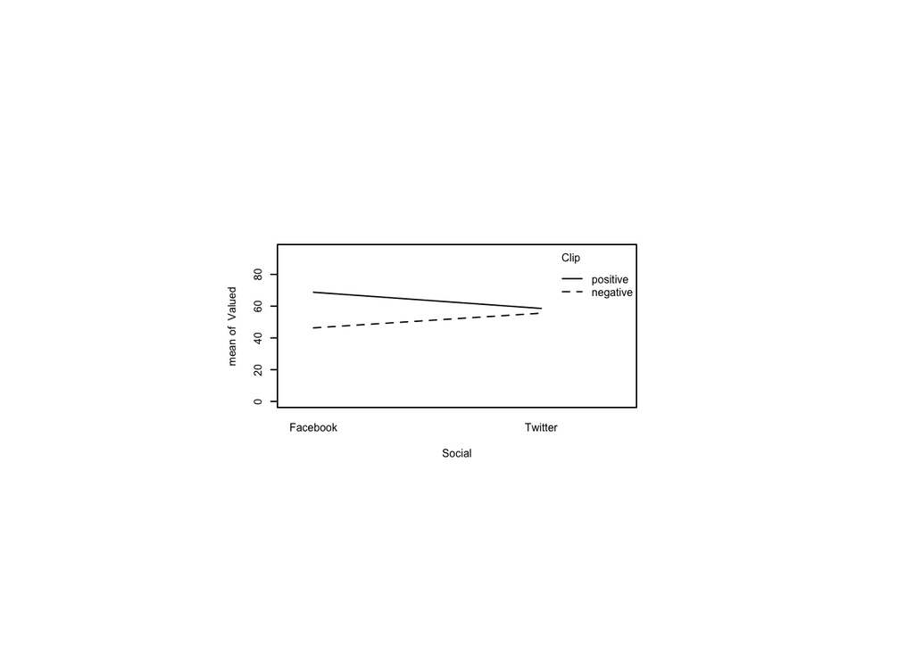

```r
par(pin=c(2.75,1.25),cex=0.5)
with(sv,interaction.plot(Social,Clip,Valued,
             ylim=c(0,max(sv$Valued))))
```

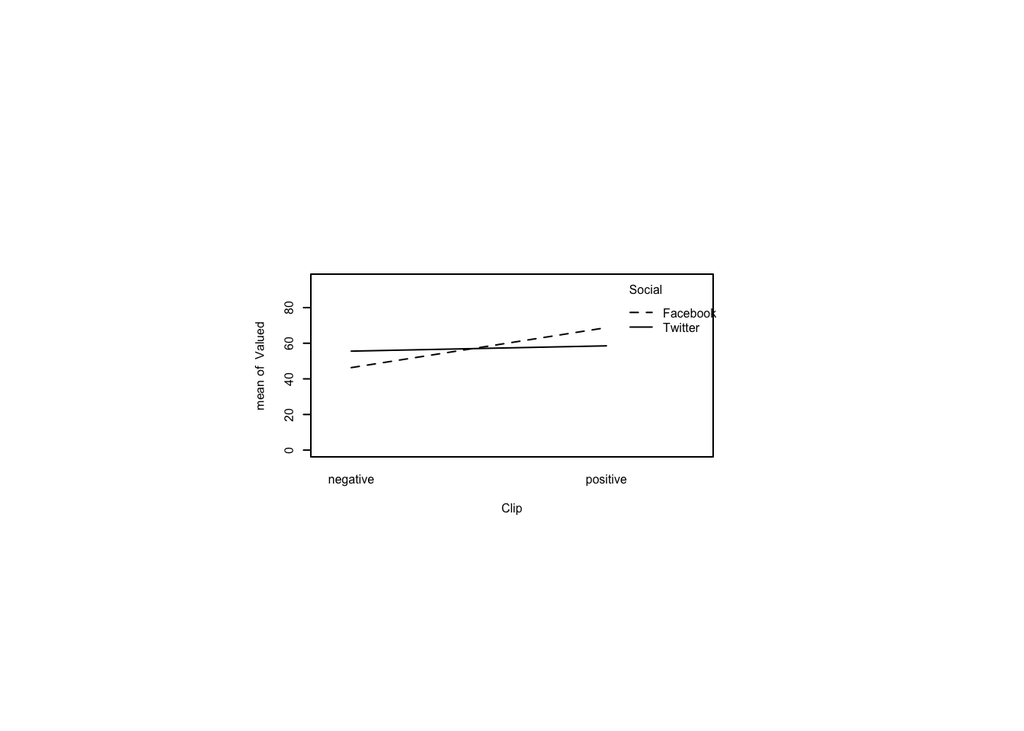

```r
with(sv,interaction.plot(Clip,Social,Valued,
             ylim=c(0,max(sv$Valued))))
```

Test for an order effect in the presentation of order of the ClipOrder or SocialOrder factor. Report the $p$-values.

```r
m<-ezANOVA(dv=Valued,within=c(ClipOrder,SocialOrder),wid=Subject,data=sv)
m$ANOVA
```

```
                 Effect DFn DFd          F         p p<.05          ges
2             ClipOrder   1  15 0.93707354 0.3483818       0.0253831509
3           SocialOrder   1  15 0.81236528 0.3816660       0.0143842018
4 ClipOrder:SocialOrder   1  15 0.01466581 0.9052172       0.0001913088
```

Conduct a factorial ANOVA on Valued by Clip and Social. Report the largest $F$-statistic.

```r
m<-ezANOVA(dv=Valued,within=c(Clip,Social),wid=Subject,data=sv)
m$ANOVA
```

```
       Effect DFn DFd          F          p p<.05          ges
2        Clip   1  15 6.99533219 0.01837880     * 0.1469889054
3      Social   1  15 0.01466581 0.90521722       0.0002340033
4 Clip:Social   1  15 6.11355984 0.02586779     * 0.0914169000
```

Conduct paired-samples $t$-tests to answer two questions. First, on Facebook, were the number of valued posts different after watching a positive or negative clip. Second, same on Twitter. Assume equal variances and use Holm’s sequential Bonferroni procedure to correct for multiple comparisons. Report the lowest adjusted $p$-value.

```r
sv.wide<-dcast(sv,Subject+Social~Clip,value.var="Valued")
head(sv.wide)
```

```
  Subject   Social negative positive
1       1 Facebook       38       85
2       1  Twitter       52       53
3       2 Facebook       73       25
4       2  Twitter       52       54
5       3 Facebook       25       95
6       3  Twitter       53       70
```

```r
f<-t.test(sv.wide[sv.wide$Social=="Facebook",]$positive,
      sv.wide[sv.wide$Social=="Facebook",]$negative,
      paired=TRUE,var.equal=TRUE)
f
```

```
    Paired t-test

data:  sv.wide[sv.wide$Social == "Facebook", ]$positive and sv.wide[sv.wide$Social == "Facebook", ]$negative
t = 2.5929, df = 15, p-value = 0.02039
alternative hypothesis: true mean difference is not equal to 0
95 percent confidence interval:
  3.993 40.882
sample estimates:
mean difference
        22.4375
```

```r
t<-t.test(sv.wide[sv.wide$Social=="Twitter",]$positive,
      sv.wide[sv.wide$Social=="Twitter",]$negative,
      paired=TRUE,var.equal=TRUE)
t
```

```
    Paired t-test

data:  sv.wide[sv.wide$Social == "Twitter", ]$positive and sv.wide[sv.wide$Social == "Twitter", ]$negative
t = 1.9926, df = 15, p-value = 0.06482
alternative hypothesis: true mean difference is not equal to 0
95 percent confidence interval:
 -0.2089939  6.2089939
sample estimates:
mean difference
              3
```

```r
p.adjust(c(f$p.value,t$p.value),method="holm")
```

```
[1] 0.04077153 0.06482275
```

Conduct a nonparametric Aligned Rank Transform Procedure on Valued by Clip and Social.

```r
m<-art(Valued~Clip*Social+(1|Subject),data=sv)
anova(m)
```

```
boundary (singular) fit: see help('isSingular')
boundary (singular) fit: see help('isSingular')
boundary (singular) fit: see help('isSingular')
```

```
Analysis of Variance of Aligned Rank Transformed Data

Table Type: Analysis of Deviance Table (Type III Wald F tests with Kenward-Roger df)
Model: Mixed Effects (lmer)
Response: art(Valued)

                     F Df Df.res     Pr(>F)
1 Clip        17.13224  1     45 0.00015089 ***
2 Social       0.49281  1     45 0.48629341
3 Clip:Social 11.31751  1     45 0.00157736  **
---
Signif. codes:   0 '***' 0.001 '**' 0.01 '*' 0.05 '.' 0.1 ' ' 1
```

Conduct interaction contrasts to discover whether the difference on Facebook was itself different from the difference on Twitter. Report the $\chi^2$ statistic.

```r
testInteractions(artlm(m,"Clip:Social"),
         pairwise=c("Clip","Social"),adjustment="holm")
```

```
boundary (singular) fit: see help('isSingular')
```

```
Chisq Test:
P-value adjustment method: holm
                                      Value     SE Df  Chisq Pr(>Chisq)
negative-positive : Facebook-Twitter -29.25 8.6946  1 11.318  0.0007678 ***
---
Signif. codes:  0 '***' 0.001 '**' 0.01 '*' 0.05 '.' 0.1 ' ' 1
```

# What if errors are not normally distributed? (Generalized linear models)

Here are three examples of generalized linear models. The first is analyzed using nominal logistic regression, the second is analyzed via ordinal logistic regression, and the third is analyzed via Poisson regression.

As Wikipedia tells us, a generalized linear model or GLM is a flexible generalization of ordinary linear regression that allows for response variables with error distribution models other than a normal distribution. There is also something called a *general* linear model but it is not the same thing as a *generalized* linear model. It is just the general form of the ordinary linear regression model: $\mathbfit{Y=X\beta+\epsilon}$.

GLMs that we examine here are good for between-subjects studies so we’ll actually recode one of our fictitious data sets to be between subjects just to have an example to use.

## Preferences among websites by males and females (GLM 1: Nominal logistic regression for preference responses)

## Multinomial distribution with logit link function

The `prefsABCsex.csv` file records preferences among three websites A, B, and C expressed by males and females. The subject number, preference and sex were recorded.

The logit link function is the log odds function, generally $\text{logit}(p)=\ln \frac{p}{1-p}$, where $p$ is the probability of an event such as choosing website A. The form of the link function is $\mathbfit{X\beta}=\ln\frac{\mu}{1-\mu}$. This is just the relationship of a matrix of predictors times a vector of parameters $\mathbfit{\beta}$ to the logit of the mean of the distribution.

```r
prefsABCsex<-read_csv("prefsABCsex.csv")
head(prefsABCsex)
```

```
# A tibble: 6 × 3
  Subject Pref  Sex
    <dbl> <chr> <chr>
1       1 C     F
2       2 C     M
3       3 B     M
4       4 C     M
5       5 C     M
6       6 B     F
```

```r
prefsABCsex$Subject<-factor(prefsABCsex$Subject)
prefsABCsex$Sex<-factor(prefsABCsex$Sex)
summary(prefsABCsex)
```

```
    Subject          Pref    Sex
 1      : 1   Length   :60   F:29
 2      : 1   N.unique : 3   M:31
 3      : 1   N.blank  : 0
 4      : 1   Min.nchar: 1
 5      : 1   Max.nchar: 1
 6      : 1
 (Other):54
```

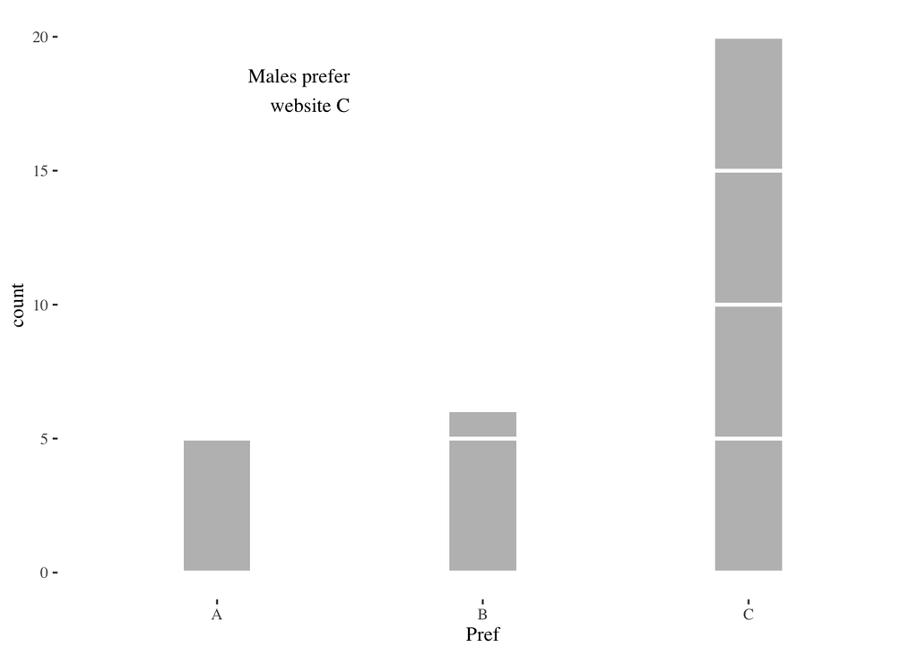

```r
ggplot(prefsABCsex[prefsABCsex$Sex == "M",],aes(Pref)) +
  theme_tufte() +
  geom_bar(width=0.25,fill="gray") +
  geom_hline(yintercept=seq(0, 20, 5), col="white", lwd=1) +
  annotate("text", x = 1.5, y = 18, adj=1,  family="serif",
    label = c("Males prefer\nwebsite C"))
```

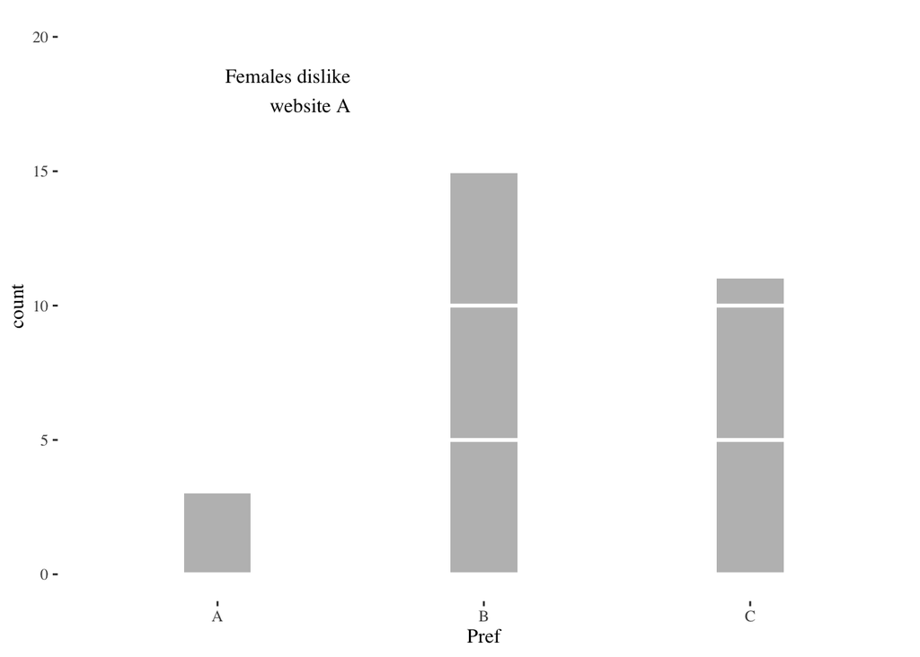

```r
ggplot(prefsABCsex[prefsABCsex$Sex == "F",],aes(Pref)) +
  theme_tufte() +
  geom_bar(width=0.25,fill="gray") +
  geom_hline(yintercept=seq(0, 20, 5), col="white", lwd=1) +
  annotate("text", x = 1.5, y = 18, adj=1,  family="serif",
    label = c("Females dislike\nwebsite A"))
```

These histograms lead us to suspect that C is preferred by males and that A is disliked by females, but we should still run tests to be convinced that the variability observed is not due to chance.

Analyze Pref by Sex using multinomial logistic regression, aka nominal logistic regression. Here we are testing for whether there is a difference between the sexes regarding their preferences.

The annotation `type=3` is borrowed from SAS and refers to one of three ways of handling an unbalanced design. This experimental design is unbalanced because there are more males than females being tested. This way of handling the unbalanced design is only valid if there are significant interactions, as hinted by the gross differences between the preceding histograms.

```r
pacman::p_load(nnet) # provides multinom()
#. pacman::p_load(car) # provides Anova()
#. set sum-to-zero contrasts for the Anova call
contrasts(prefsABCsex$Sex) <- "contr.sum"
m<-multinom(Pref~Sex, data=prefsABCsex)
Anova(m, type=3)
```

```
Analysis of Deviance Table (Type III tests)

Response: Pref
    LR Chisq Df Pr(>Chisq)
Sex   7.0744  2    0.02909 *
---
Signif. codes:  0 '***' 0.001 '**' 0.01 '*' 0.05 '.' 0.1 ' ' 1
```

The Analysis of Deviance table tells us that there is a significant main effect for Sex. It does not tell us more detail but motivates pairwise tests to get more detail. If there were no significant effect, pairwise tests would not be warranted.

Pairwise tests tell which of the bins are over or under populated based on the assumption that each bin should contain one third of the observations (hence `p=1/3`). When making multiple comparisons we would overstate the significance of the differences so we use Holm’s sequential Bonferroni procedure to correct this.

```r
ma<-binom.test(sum(prefsABCsex[prefsABCsex$Sex == "M",]$Pref == "A"),
           nrow(prefsABCsex[prefsABCsex$Sex == "M",]), p=1/3)
mb<-binom.test(sum(prefsABCsex[prefsABCsex$Sex == "M",]$Pref == "B"),
           nrow(prefsABCsex[prefsABCsex$Sex == "M",]), p=1/3)
mc<-binom.test(sum(prefsABCsex[prefsABCsex$Sex == "M",]$Pref == "C"),
           nrow(prefsABCsex[prefsABCsex$Sex == "M",]), p=1/3)
#. correct for multiple comparisons
p.adjust(c(ma$p.value, mb$p.value, mc$p.value), method="holm")
```

```
[1] 0.109473564 0.126622172 0.001296754
```

```r
fa<-binom.test(sum(prefsABCsex[prefsABCsex$Sex == "F",]$Pref == "A"),
           nrow(prefsABCsex[prefsABCsex$Sex == "F",]), p=1/3)
fb<-binom.test(sum(prefsABCsex[prefsABCsex$Sex == "F",]$Pref == "B"),
           nrow(prefsABCsex[prefsABCsex$Sex == "F",]), p=1/3)
fc<-binom.test(sum(prefsABCsex[prefsABCsex$Sex == "F",]$Pref == "C"),
           nrow(prefsABCsex[prefsABCsex$Sex == "F",]), p=1/3)
#. correct for multiple comparisons
p.adjust(c(fa$p.value, fb$p.value, fc$p.value), method="holm")
```

```
[1] 0.02703274 0.09447821 0.69396951
```

The preceding tests confirm what we suspected from looking at histograms: males prefer C and females dislike A. We see this by looking at the adjusted $p$-values, where the first row, third value is significant and the second row, first value is significant.

How would we write this up in a report? We could make the following claim. We tested the main effect for sex and found a significant result, $\chi^2_2=7.1, p<0.05$. An exact binomial test found the preference among males for website C greater than chance, $p<0.01$. An exact binomial test found the preference among females against website A greater than chance, $p<0.05$. No other significant differences were found.

## Judgments of perceived effort (GLM 2: Ordinal logistic regression for Likert responses)

## Multinomial distribution with cumulative logit link function

In this example, users are either searching, scrolling or using voice to find contacts in a smartphone address book. The time it takes to find a certain number of contacts, the perceived effort, and the number of errors are all recorded. Of interest now is the perceived effort, recorded on a Likert scale. A Likert scale can not be normally distributed because of the restrictions on the ends and is not likely to even look vaguely normal.

The cumulative logit link function is like the logit link function:

$$\text{logit}(P(Y\leqslant j|x))=\ln\frac{P(Y\leqslant j|x)}{1-P(Y\leqslant j|x)} \text{ where }Y=1,2,\ldots,J$$

In this case $J$ ranges from 1 to 7.

Read in the data and examine it. We see that it is a within-subjects study but it is a fictitious study anyway so we will recode it as if it were a between-subjects study. Then we will be able to apply the following techniques, which we would have to modify for a within-subjects study.

```r
srchscrlvce<-read_csv("srchscrlvce.csv")
head(srchscrlvce)
```

```
# A tibble: 6 × 6
  Subject Technique Order  Time Errors Effort
    <dbl> <chr>     <dbl> <dbl>  <dbl>  <dbl>
1       1 Search        1    98      4      5
2       1 Scroll        2   152      0      6
3       2 Search        2    57      2      2
4       2 Scroll        1   148      0      3
5       3 Search        1    86      3      2
6       3 Scroll        2   160      0      4
```

```r
srchscrlvce$Subject<-(1:nrow(srchscrlvce)) # recode as between-subjects
srchscrlvce$Subject<-factor(srchscrlvce$Subject)
srchscrlvce$Technique<-factor(srchscrlvce$Technique)
srchscrlvce$Order<-NULL # drop order, n/a for between-subjects
head(srchscrlvce) # verify
```

```
# A tibble: 6 × 5
  Subject Technique  Time Errors Effort
  <fct>   <fct>     <dbl>  <dbl>  <dbl>
1 1       Search       98      4      5
2 2       Scroll      152      0      6
3 3       Search       57      2      2
4 4       Scroll      148      0      3
5 5       Search       86      3      2
6 6       Scroll      160      0      4
```

```r
summary(srchscrlvce)
```

```
    Subject    Technique       Time           Errors         Effort
 1      : 1   Scroll:20   Min.   : 49.0   Min.   :0.00   Min.   :1.00
 2      : 1   Search:20   1st Qu.: 86.0   1st Qu.:1.00   1st Qu.:3.00
 3      : 1   Voice :20   Median : 97.0   Median :2.00   Median :4.00
 4      : 1               Mean   :106.2   Mean   :2.75   Mean   :4.15
 5      : 1               3rd Qu.:128.0   3rd Qu.:4.00   3rd Qu.:5.00
 6      : 1               Max.   :192.0   Max.   :9.00   Max.   :7.00
 (Other):54
```

A good description of Effort is the median and quantiles. Another good description is the mean and standard deviation.

```r
plyr::ddply(srchscrlvce, ~ Technique,
       function(data) summary(data$Effort))
```

```
  Technique Min. 1st Qu. Median Mean 3rd Qu. Max.
1    Scroll    1    3.00      4 4.40    6.00    7
2    Search    1    3.00      4 3.60    4.25    5
3     Voice    1    3.75      5 4.45    5.25    6
```

```r
plyr::ddply(srchscrlvce, ~ Technique,
       summarize, Effort.mean=mean(Effort), Effort.sd=sd(Effort))
```

```
  Technique Effort.mean Effort.sd
1    Scroll        4.40  1.698296
2    Search        3.60  1.187656
3     Voice        4.45  1.356272
```

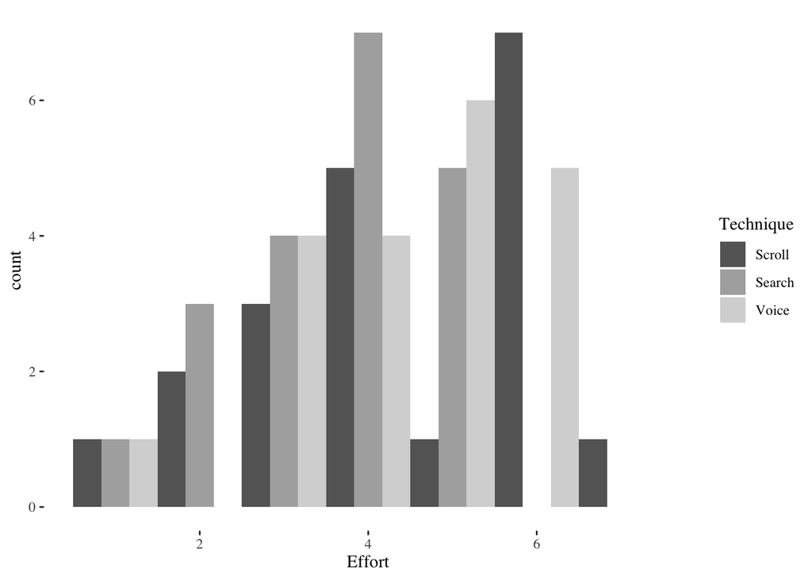

```r
par(cex=0.6)
ggplot(srchscrlvce,aes(Effort,fill=Technique)) +
  geom_histogram(bins=7,alpha=0.8,position="dodge") +
  scale_color_grey() +
  scale_fill_grey() +
  theme_tufte()
```

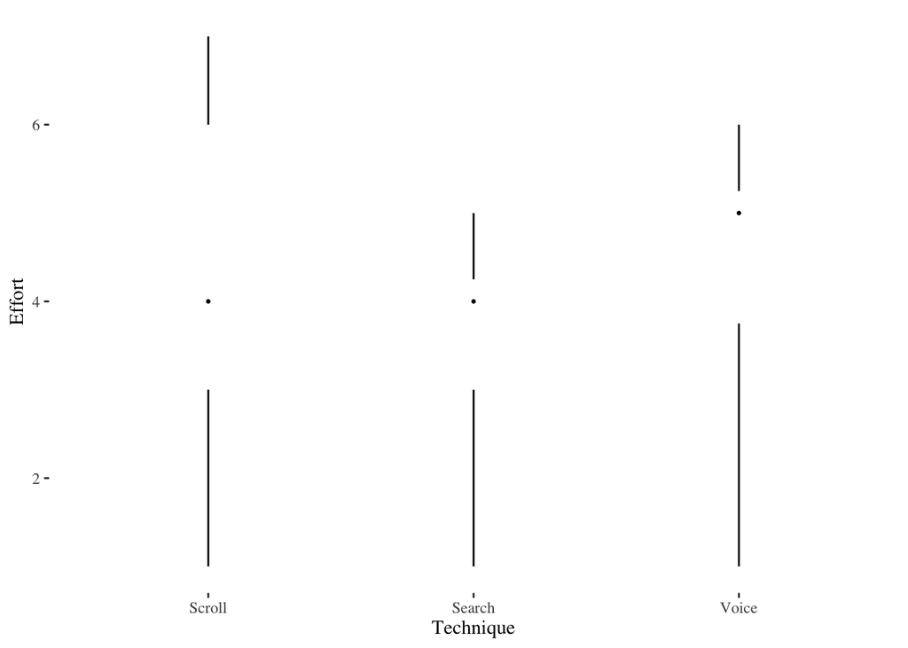

```r
ggplot(srchscrlvce,aes(Technique,Effort,fill=Technique)) +
  geom_tufteboxplot(show.legend=FALSE) +
  theme_tufte()
```

The boxplots (these are Tufte-style boxplots) are not encouraging. We may not find a significant difference among these three techniques but let us try anyway. We analyze Effort Likert ratings by Technique using ordinal logistic regression.

```r
#. pacman::p_load(MASS) # provides polr()
#. pacman::p_load(car) # provides Anova()
srchscrlvce$Effort <- ordered(srchscrlvce$Effort)
#. set sum-to-zero contrasts for the Anova call
contrasts(srchscrlvce$Technique) <- "contr.sum"
m <- polr(Effort ~ Technique, data=srchscrlvce, Hess=TRUE) # ordinal logistic
Anova(m, type=3)
```

```
Analysis of Deviance Table (Type III tests)

Response: Effort
          LR Chisq Df Pr(>Chisq)
Technique   4.5246  2     0.1041
```

Post hoc pairwise comparisons are NOT justified due to lack of significance but here’s how we would do them, just for completeness. `Tukey` means to compare all pairs and `holm` is the adjustment due to the double-counting that overstates the significance.

```r
summary(glht(m, mcp(Technique="Tukey")), test=adjusted(type="holm"))
```

```
     Simultaneous Tests for General Linear Hypotheses

Multiple Comparisons of Means: Tukey Contrasts


Fit: polr(formula = Effort ~ Technique, data = srchscrlvce, Hess = TRUE)

Linear Hypotheses:
                      Estimate Std. Error z value Pr(>|z|)
Search - Scroll == 0 -1.016610   0.584614  -1.739    0.191
Voice - Scroll == 0   0.007397   0.587700   0.013    0.990
Voice - Search == 0   1.024007   0.552298   1.854    0.191
(Adjusted p values reported -- holm method)
```

How would we express this in a report? We would simply say that we found no significant differences between the three techniques.

## Counting errors in a task (GLM 3: Poisson regression for count responses)

## Poisson distribution with log link function

Using the same data but now focus on the Errors column instead of effort. Errors likely have a Poisson distribution. The log link function is just $\mathbfit{X\beta}=\ln(\mu)$ rather than the more elaborate logit link function we saw before.

```r
plyr::ddply(srchscrlvce, ~ Technique,
             function(data) summary(data$Errors))
```

```
  Technique Min. 1st Qu. Median Mean 3rd Qu. Max.
1    Scroll    0    0.00    0.5 0.70    1.00    2
2    Search    1    2.00    2.5 2.50    3.00    4
3     Voice    2    3.75    5.0 5.05    6.25    9
```

```r
plyr::ddply(srchscrlvce, ~ Technique, summarize,
             Errors.mean=mean(Errors), Errors.sd=sd(Errors))
```

```
  Technique Errors.mean Errors.sd
1    Scroll        0.70 0.8013147
2    Search        2.50 1.0513150
3     Voice        5.05 1.9049796
```

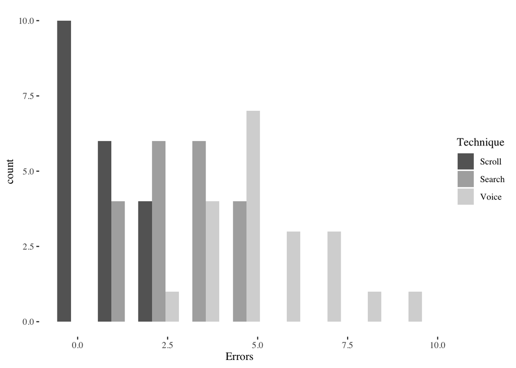

```r
par(cex=0.6)
ggplot(srchscrlvce,aes(Errors,fill=Technique)) +
  geom_histogram(bins=9,alpha=0.8,position="dodge") +
  scale_color_grey() +
  scale_fill_grey() +
  theme_tufte()
```

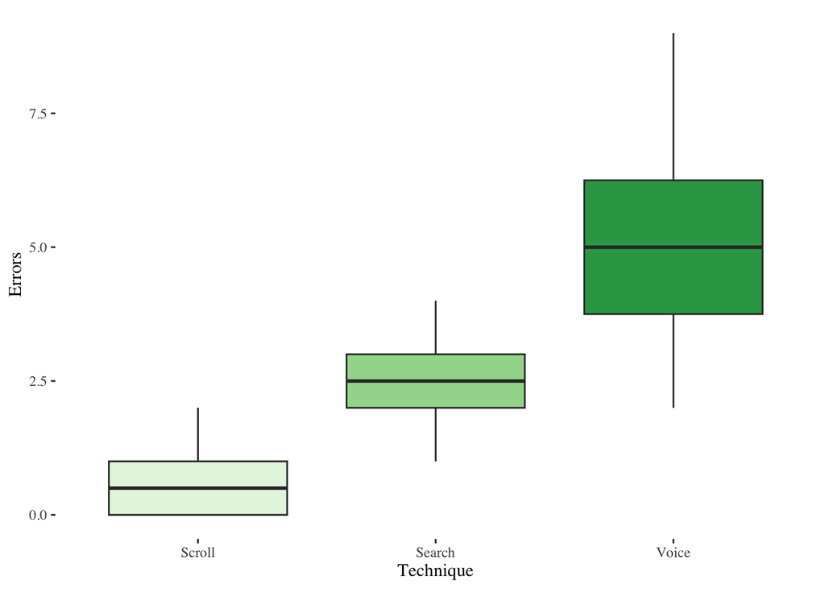

```r
ggplot(srchscrlvce,aes(Technique,Errors,fill=Technique)) +
  geom_boxplot(show.legend=FALSE) +
  scale_fill_brewer(palette="Greens") +
  theme_tufte()
```

These boxplots are very encouraging. There appears to be a clear difference between all three of these techniques. Notice that you could draw horizontal lines across the plot without intersecting the boxes. That represents a high degree of separation.

Now verify that these data are Poisson-distributed with a goodness-of-fit test for each technique. If the results are *not* significant, we expect that the data do not deviate significantly from what we would expect of a Poisson distribution.

```r
#. pacman::p_load(fitdistrplus)
fit<-fitdist(srchscrlvce[srchscrlvce$Technique == "Search",]$Errors,
              "pois", discrete=TRUE)
gofstat(fit)
```

```
Chi-squared statistic:  1.522231
Degree of freedom of the Chi-squared distribution:  2
Chi-squared p-value:  0.4671449
   the p-value may be wrong with some theoretical counts < 5
Chi-squared table:
     obscounts theocounts
<= 1  4.000000   5.745950
<= 2  6.000000   5.130312
<= 3  6.000000   4.275260
> 3   4.000000   4.848477

Goodness-of-fit criteria
                               1-mle-pois
Akaike's Information Criterion   65.61424
Bayesian Information Criterion   66.60997
```

```r
fit<-fitdist(srchscrlvce[srchscrlvce$Technique == "Scroll",]$Errors,
              "pois", discrete=TRUE)
gofstat(fit)
```

```
Chi-squared statistic:  0.3816087
Degree of freedom of the Chi-squared distribution:  1
Chi-squared p-value:  0.5367435
   the p-value may be wrong with some theoretical counts < 5
Chi-squared table:
     obscounts theocounts
<= 0 10.000000   9.931706
<= 1  6.000000   6.952194
> 1   4.000000   3.116100

Goodness-of-fit criteria
                               1-mle-pois
Akaike's Information Criterion   45.53208
Bayesian Information Criterion   46.52781
```

```r
fit<-fitdist(srchscrlvce[srchscrlvce$Technique == "Voice",]$Errors,
              "pois", discrete=TRUE)
gofstat(fit)
```

```
Chi-squared statistic:  0.1611327
Degree of freedom of the Chi-squared distribution:  3
Chi-squared p-value:  0.9836055
   the p-value may be wrong with some theoretical counts < 5
Chi-squared table:
     obscounts theocounts
<= 3  5.000000   5.161546
<= 4  4.000000   3.473739
<= 5  3.000000   3.508476
<= 6  3.000000   2.952967
> 6   5.000000   4.903272

Goodness-of-fit criteria
                               1-mle-pois
Akaike's Information Criterion   84.19266
Bayesian Information Criterion   85.18839
```

All three of the above goodness of fit tests tell us that there is no evidence of deviation from a Poisson distribution. Since we are now convinced of the Poisson distribution for each of the three techniques, analyze the errors using Poisson regression.

We’ve been saying “set sum-to-zero contrasts for the Anova call” but what does that mean? Contrasts are linear combinations used in ANOVA. As Wikipedia defines it, a contrast is a linear combination $\sum^t_{i=1}a_i\theta_i$, where each $\theta_i$ is a statistic and the $a_i$ values sum to zero. Typically, the $a_i$ values are $1$ and $-1$. A simple contrast represents a difference between means and is used in ANOVA. In R, they are invisible if you use Type I ANOVA, but have to be specified as follows if using a Type III ANOVA. The default `anova()` function is Type I but we’re using Type III, available from the `Anova()` function in the `car` package.

A minor detail is that we don’t really need to use `Anova()` here instead of `anova()` because the study is balanced, meaning that it has the same number of observations in each condition. The only reason for using `Anova()` on this data is that it gives a better-looking output. The `anova()` function would just display the $\chi^2$ statistic without the associated $p$-value.

```r
contrasts(srchscrlvce$Technique) <- "contr.sum"
#. family parameter identifies both distribution and link fn
m <- glm(Errors ~ Technique, data=srchscrlvce, family=poisson)
Anova(m, type=3)
```

```
Analysis of Deviance Table (Type III tests)

Response: Errors
          LR Chisq Df Pr(>Chisq)
Technique    74.93  2  < 2.2e-16 ***
---
Signif. codes:  0 '***' 0.001 '**' 0.01 '*' 0.05 '.' 0.1 ' ' 1
```

Because the Analysis of Deviance table shows a significant $\chi^2$ value and corresponding $p$-value, we are justified to conduct pairwise comparisons among levels of Technique.

```r
#. pacman::p_load(multcomp)
summary(glht(m, mcp(Technique="Tukey")), test=adjusted(type="holm"))
```

```
     Simultaneous Tests for General Linear Hypotheses

Multiple Comparisons of Means: Tukey Contrasts


Fit: glm(formula = Errors ~ Technique, family = poisson, data = srchscrlvce)

Linear Hypotheses:
                     Estimate Std. Error z value Pr(>|z|)
Search - Scroll == 0   1.2730     0.3024   4.210 5.11e-05 ***
Voice - Scroll == 0    1.9761     0.2852   6.929 1.27e-11 ***
Voice - Search == 0    0.7031     0.1729   4.066 5.11e-05 ***
---
Signif. codes:  0 '***' 0.001 '**' 0.01 '*' 0.05 '.' 0.1 ' ' 1
(Adjusted p values reported -- holm method)
```

We see from the table that all three differences are significant. We could have guessed this result from glancing at the boxplot above, but it is valuable to have statistical evidence that this is not a chance difference.

# More experiments without normally distributed errors (More generalized linear models)

## Preference between touchpads vs trackballs by non / disabled people and males / females

This study examines whether participants of either sex with or without a disability prefer touchpads or trackballs. Start by examining the data and determining how many participants are involved.

```r
dps<-read_csv("deviceprefssex.csv")
dps$Subject<-as.factor(dps$Subject)
dps$Disability<-as.factor(dps$Disability)
dps$Sex<-as.factor(dps$Sex)
dps$Pref<-as.factor(dps$Pref)
summary(dps)
```

```
    Subject   Disability Sex           Pref
 1      : 1   0:18       F:15   touchpad :21
 2      : 1   1:12       M:15   trackball: 9
 3      : 1
 4      : 1
 5      : 1
 6      : 1
 (Other):24
```

Use binomial regression to examine Pref by Disability and Sex. Report the $p$-value of the interaction of Disability$\times$Sex.

```r
contrasts(dps$Disability) <- "contr.sum"
contrasts(dps$Sex) <- "contr.sum"
m<-glm(Pref ~ Disability*Sex, data=dps, family=binomial)
Anova(m, type=3)
```

```
Analysis of Deviance Table (Type III tests)

Response: Pref
               LR Chisq Df Pr(>Chisq)
Disability      10.4437  1   0.001231 **
Sex              2.8269  1   0.092695 .
Disability:Sex   0.6964  1   0.403997
---
Signif. codes:  0 '***' 0.001 '**' 0.01 '*' 0.05 '.' 0.1 ' ' 1
```

Now use multinomial regression for the same task and report the corresponding $p$-value.

```r
#. pacman::p_load(nnet)
contrasts(dps$Disability) <- "contr.sum"
contrasts(dps$Sex) <- "contr.sum"
m<-multinom(Pref~Disability*Sex, data=dps)
Anova(m, type=3)
```

```
Analysis of Deviance Table (Type III tests)

Response: Pref
               LR Chisq Df Pr(>Chisq)
Disability      10.4434  1   0.001231 **
Sex              2.8267  1   0.092709 .
Disability:Sex   0.6961  1   0.404083
---
Signif. codes:  0 '***' 0.001 '**' 0.01 '*' 0.05 '.' 0.1 ' ' 1
```

Now conduct post-hoc binomial tests for each Disability$\times$Sex combination.

```r
m0<-binom.test(sum(dps[dps$Sex == "M" & dps$Disability == "0",]$Pref == "touchpad"),
               nrow(dps[dps$Sex == "M" & dps$Disability == "0",]),p=1/2)
m1<-binom.test(sum(dps[dps$Sex == "M" & dps$Disability == "1",]$Pref == "touchpad"),
               nrow(dps[dps$Sex == "M" & dps$Disability == "1",]),p=1/2)

f0<-binom.test(sum(dps[dps$Sex == "F" & dps$Disability == "0",]$Pref == "touchpad"),
               nrow(dps[dps$Sex == "F" & dps$Disability == "0",]),p=1/2)
f1<-binom.test(sum(dps[dps$Sex == "F" & dps$Disability == "1",]$Pref == "touchpad"),
               nrow(dps[dps$Sex == "F" & dps$Disability == "1",]),p=1/2)

p.adjust(c(m0$p.value, m1$p.value, f0$p.value,f1$p.value), method="holm")
```

```
[1] 0.0625000 1.0000000 0.1962891 1.0000000
```

## Handwriting recognition speed between different tools and right-handed vs left-handed people

This study examined three handwriting recognizers, A, B, and C and participants who are either right-handed or left-handed. The response is the number of incorrectly recognized handwritten words out of every 100 handwritten words. Examine the data and tell how many participants were involved.

```r
hw<-read_csv("hwreco.csv")
hw$Subject<-factor(hw$Subject)
hw$Recognizer<-factor(hw$Recognizer)
hw$Hand<-factor(hw$Hand)
summary(hw)
```

```
    Subject   Recognizer    Hand        Errors
 1      : 1   A:17       Left :25   Min.   : 1.00
 2      : 1   B:17       Right:25   1st Qu.: 3.00
 3      : 1   C:16                  Median : 4.00
 4      : 1                         Mean   : 4.38
 5      : 1                         3rd Qu.: 6.00
 6      : 1                         Max.   :11.00
 (Other):44
```

Create an interaction plot of Recognizer on the $x$-axis and Hand as the traces and tell how many times the traces cross.

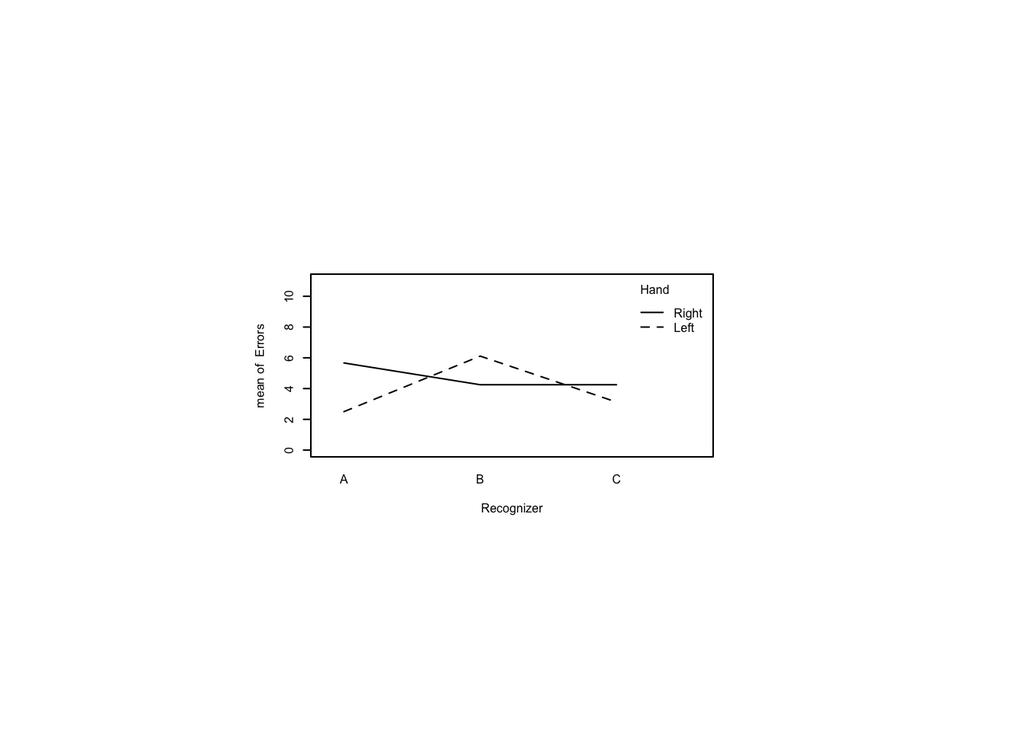

```r
par(pin=c(2.75,1.25),cex=0.5)
with(hw,interaction.plot(Recognizer,Hand,Errors,
                  ylim=c(0,max(hw$Errors))))
```

Test whether the Errors of each Recognizer fit a Poisson distribution. First fit the Poisson distribution using `fitdist()`, then test the fit using `gofstat()`. The null hypothesis of this test is that the data do not deviate from a Poisson distribution.

```r
#. pacman::p_load(fitdistrplus)
fit<-fitdist(hw[hw$Recognizer == "A",]$Errors,
              "pois", discrete=TRUE)
gofstat(fit)
```

```
Chi-squared statistic:  1.807852
Degree of freedom of the Chi-squared distribution:  2
Chi-squared p-value:  0.4049767
   the p-value may be wrong with some theoretical counts < 5
Chi-squared table:
     obscounts theocounts
<= 2  4.000000   3.627277
<= 3  5.000000   3.168895
<= 5  4.000000   6.072436
> 5   4.000000   4.131392

Goodness-of-fit criteria
                               1-mle-pois
Akaike's Information Criterion   75.86792
Bayesian Information Criterion   76.70113
```

```r
fit<-fitdist(hw[hw$Recognizer == "B",]$Errors,
              "pois", discrete=TRUE)
gofstat(fit)
```

```
Chi-squared statistic:  0.9192556
Degree of freedom of the Chi-squared distribution:  2
Chi-squared p-value:  0.6315187
   the p-value may be wrong with some theoretical counts < 5
Chi-squared table:
     obscounts theocounts
<= 3  5.000000   3.970124
<= 5  4.000000   5.800601
<= 6  3.000000   2.588830
> 6   5.000000   4.640444

Goodness-of-fit criteria
                               1-mle-pois
Akaike's Information Criterion   78.75600
Bayesian Information Criterion   79.58921
```

```r
fit<-fitdist(hw[hw$Recognizer == "C",]$Errors,
              "pois", discrete=TRUE)
gofstat(fit)
```

```
Chi-squared statistic:  0.3521272
Degree of freedom of the Chi-squared distribution:  2
Chi-squared p-value:  0.8385646
   the p-value may be wrong with some theoretical counts < 5
Chi-squared table:
     obscounts theocounts
<= 2  5.000000   4.600874
<= 3  4.000000   3.347372
<= 4  3.000000   3.085858
> 4   4.000000   4.965897

Goodness-of-fit criteria
                               1-mle-pois
Akaike's Information Criterion   70.89042
Bayesian Information Criterion   71.66301
```

Now use Poisson regression to examine Errors by Recommender and Hand. Report the $p$-value for the Recognizer$\times$Hand interaction.

```r
#. pacman::p_load(car)
contrasts(hw$Recognizer) <- "contr.sum"
contrasts(hw$Hand) <- "contr.sum"
m<-glm(Errors ~ Recognizer*Hand, data=hw, family=poisson)
Anova(m, type=3)
```

```
Analysis of Deviance Table (Type III tests)

Response: Errors
                LR Chisq Df Pr(>Chisq)
Recognizer        4.8768  2   0.087299 .
Hand              3.1591  1   0.075504 .
Recognizer:Hand  12.9682  2   0.001528 **
---
Signif. codes:  0 '***' 0.001 '**' 0.01 '*' 0.05 '.' 0.1 ' ' 1
```

Conduct planned comparisons between left and right errors for each recognizer. Using `glht()` and `lsm()` will give all comparisons and we only want three so don’t correct for multiple comparisons automatically. That would overcorrect. Instead, extract the three relevant $p$-values manually and and use `p.adjust()` to correct for those.

```r
#. pacman::p_load(multcomp) # for glht
#. pacman::p_load(lsmeans) # for lsm
summary(glht(m, lsm(pairwise ~ Recognizer * Hand)),
        test=adjusted(type="none"))
```

```
     Simultaneous Tests for General Linear Hypotheses

Fit: glm(formula = Errors ~ Recognizer * Hand, family = poisson, data = hw)

Linear Hypotheses:
                         Estimate Std. Error z value Pr(>|z|)
A Left - B Left == 0   -8.938e-01  2.611e-01  -3.423 0.000619 ***
A Left - C Left == 0   -2.231e-01  3.000e-01  -0.744 0.456990
A Left - A Right == 0  -8.183e-01  2.638e-01  -3.102 0.001925 **
A Left - B Right == 0  -5.306e-01  2.818e-01  -1.883 0.059702 .
A Left - C Right == 0  -5.306e-01  2.818e-01  -1.883 0.059702 .
B Left - C Left == 0    6.707e-01  2.412e-01   2.780 0.005428 **
B Left - A Right == 0   7.551e-02  1.944e-01   0.388 0.697704
B Left - B Right == 0   3.632e-01  2.182e-01   1.665 0.095955 .
B Left - C Right == 0   3.632e-01  2.182e-01   1.665 0.095955 .
C Left - A Right == 0  -5.952e-01  2.441e-01  -2.438 0.014779 *
C Left - B Right == 0  -3.075e-01  2.635e-01  -1.167 0.243171
C Left - C Right == 0  -3.075e-01  2.635e-01  -1.167 0.243171
A Right - B Right == 0  2.877e-01  2.214e-01   1.299 0.193822
A Right - C Right == 0  2.877e-01  2.214e-01   1.299 0.193822
B Right - C Right == 0 -3.331e-16  2.425e-01   0.000 1.000000
---
Signif. codes:  0 '***' 0.001 '**' 0.01 '*' 0.05 '.' 0.1 ' ' 1
(Adjusted p values reported -- none method)
```

```r
p.adjust(c(0.001925,0.095955,0.243171),method="holm")
```

```
[1] 0.005775 0.191910 0.243171
```

The above analyses suggest that the error counts were Poisson-distributed. The above analyses suggest that there was a significant Recognizer$\times$Hand interaction. The above analyses suggest that for recognizer A, there were significantly more errors for right-handed participants than for left-handed participants.

## Ease of booking international or domestic flights on three different services

This study describes flight bookings using one of three services, Expedia, Orbitz, or Priceline. Each booking was either International or Domestic and the Ease of each interaction was recorded on a 7 point Likert scale where 7 was easiest. Examine the data and determine the number of participants in the study.

```r
bf<-read_csv("bookflights.csv")
bf$Subject<-factor(bf$Subject)
bf$International<-factor(bf$International)
bf$Website<-factor(bf$Website)
bf$International<-factor(bf$International)
bf$Ease<-as.ordered(bf$Ease)
summary(bf)
```

```
    Subject         Website    International Ease
 1      :  1   Expedia  :200   0:300         1: 87
 2      :  1   Orbitz   :200   1:300         2: 58
 3      :  1   Priceline:200                 3:108
 4      :  1                                 4:107
 5      :  1                                 5: 95
 6      :  1                                 6: 71
 (Other):594                                 7: 74
```

Draw an interaction plot with Website on the x-axis and International as the traces. Determine how many times the traces cross.

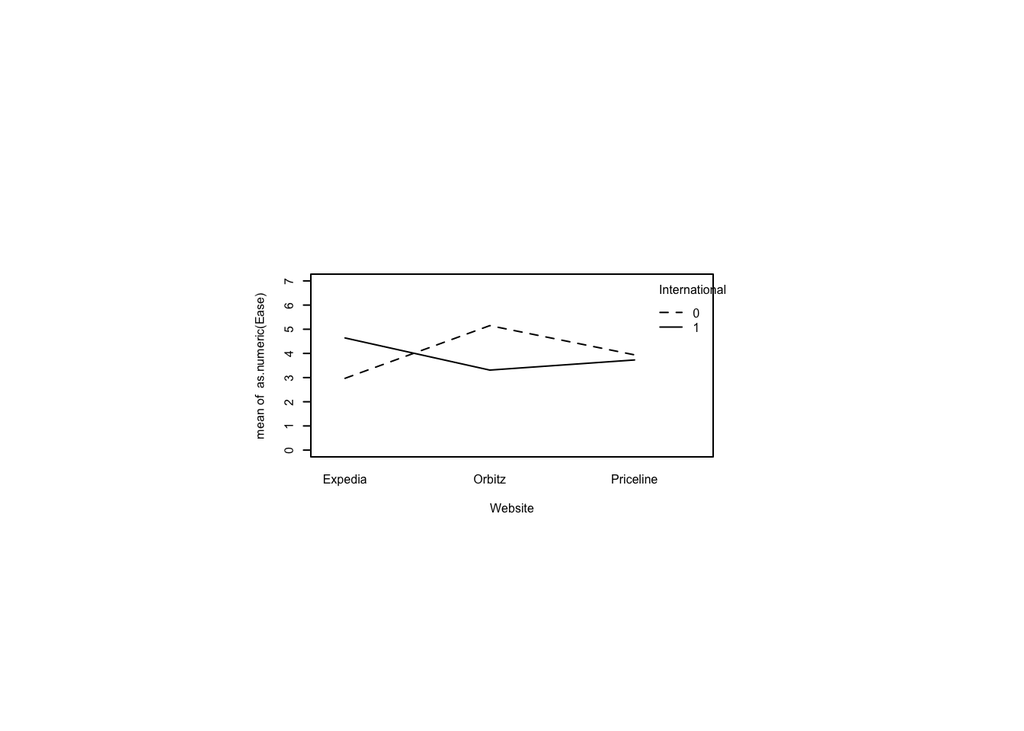

```r
par(pin=c(2.75,1.25),cex=0.5)
with(bf,interaction.plot(Website,International,as.numeric(Ease),
                  ylim=c(0,max(as.numeric(bf$Ease)))))
```

Use ordinal logistic regression to examine Ease by Website and International. Report the $p$-value of the Website main effect.

```r
#. pacman::p_load(MASS) # provides polr()
#. pacman::p_load(car) # provides Anova()
#. set sum-to-zero contrasts for the Anova call
contrasts(bf$Website) <- "contr.sum"
contrasts(bf$International) <- "contr.sum"
m <- polr(Ease ~ Website*International, data=bf, Hess=TRUE)
Anova(m, type=3)
```

```
Analysis of Deviance Table (Type III tests)

Response: Ease
                      LR Chisq Df Pr(>Chisq)
Website                  6.811  2    0.03319 *
International            0.668  1    0.41383
Website:International   90.590  2    < 2e-16 ***
---
Signif. codes:  0 '***' 0.001 '**' 0.01 '*' 0.05 '.' 0.1 ' ' 1
```

Conduct three pairwise comparisons of Ease between domestic and international for each service. Report the largest adjusted $p$-value. Use the same technique as above where you extracted the relevant unadjusted $p$-values manually and used `p.adjust()` to adjust them.

```r
summary(as.glht(pairs(lsmeans(m, pairwise ~ Website * International))),
        test=adjusted(type="none"))
```

```
     Simultaneous Tests for General Linear Hypotheses

Linear Hypotheses:
                                                         Estimate Std. Error
Expedia International0 - Orbitz International0 == 0       -2.1442     0.2619
Expedia International0 - Priceline International0 == 0    -0.9351     0.2537
Expedia International0 - Expedia International1 == 0      -1.6477     0.2570
Expedia International0 - Orbitz International1 == 0       -0.3217     0.2490
Expedia International0 - Priceline International1 == 0    -0.7563     0.2517
Orbitz International0 - Priceline International0 == 0      1.2091     0.2555
Orbitz International0 - Expedia International1 == 0        0.4965     0.2505
Orbitz International0 - Orbitz International1 == 0         1.8225     0.2571
Orbitz International0 - Priceline International1 == 0      1.3879     0.2546
Priceline International0 - Expedia International1 == 0    -0.7126     0.2518
Priceline International0 - Orbitz International1 == 0      0.6134     0.2497
Priceline International0 - Priceline International1 == 0   0.1789     0.2501
Expedia International1 - Orbitz International1 == 0        1.3260     0.2524
Expedia International1 - Priceline International1 == 0     0.8914     0.2506
Orbitz International1 - Priceline International1 == 0     -0.4345     0.2477
                                                         z value Pr(>|z|)
Expedia International0 - Orbitz International0 == 0       -8.189 2.22e-16 ***
Expedia International0 - Priceline International0 == 0    -3.686 0.000228 ***
Expedia International0 - Expedia International1 == 0      -6.411 1.44e-10 ***
Expedia International0 - Orbitz International1 == 0       -1.292 0.196380
Expedia International0 - Priceline International1 == 0    -3.004 0.002663 **
Orbitz International0 - Priceline International0 == 0      4.732 2.22e-06 ***
Orbitz International0 - Expedia International1 == 0        1.982 0.047498 *
Orbitz International0 - Orbitz International1 == 0         7.089 1.35e-12 ***
Orbitz International0 - Priceline International1 == 0      5.452 4.99e-08 ***
Priceline International0 - Expedia International1 == 0    -2.830 0.004659 **
Priceline International0 - Orbitz International1 == 0      2.457 0.014023 *
Priceline International0 - Priceline International1 == 0   0.715 0.474476
Expedia International1 - Orbitz International1 == 0        5.254 1.49e-07 ***
Expedia International1 - Priceline International1 == 0     3.557 0.000375 ***
Orbitz International1 - Priceline International1 == 0     -1.754 0.079408 .
---
Signif. codes:  0 '***' 0.001 '**' 0.01 '*' 0.05 '.' 0.1 ' ' 1
(Adjusted p values reported -- none method)
```

```r
p.adjust(c(1.44e-10,1.35e-12,0.474476),method="holm")
```

```
[1] 2.88000e-10 4.05000e-12 4.74476e-01
```

The above analyses indicate a significant main effect of Website on Ease. The above analyses indicate a significant interaction between Website and International. Expedia was perceived as significantly easier for booking international flights than domestic flights. Orbitz, on the other hand, was perceived as significantly easier for booking domestic flights than international flights.

# Same person using different tools (Within subjects studies)

## Two search engines compared

```r
ws<-read_csv("websearch2.csv")
```

How many subjects took part in this study?

```r
ws$Subject<-factor(ws$Subject)
ws$Engine<-factor(ws$Engine)
summary(ws)
```

```
    Subject      Engine       Order        Searches         Effort
 1      : 2   Bing  :30   Min.   :1.0   Min.   : 89.0   Min.   :1.00
 2      : 2   Google:30   1st Qu.:1.0   1st Qu.:135.8   1st Qu.:2.00
 3      : 2               Median :1.5   Median :156.5   Median :4.00
 4      : 2               Mean   :1.5   Mean   :156.9   Mean   :3.90
 5      : 2               3rd Qu.:2.0   3rd Qu.:175.2   3rd Qu.:5.25
 6      : 2               Max.   :2.0   Max.   :241.0   Max.   :7.00
 (Other):48
```

```r
tail(ws)
```

```
# A tibble: 6 × 5
  Subject Engine Order Searches Effort
  <fct>   <fct>  <dbl>    <dbl>  <dbl>
1 28      Google     2      131      4
2 28      Bing       1      192      4
3 29      Google     1      162      5
4 29      Bing       2      163      3
5 30      Google     2      146      5
6 30      Bing       1      137      2
```

Thirty subjects participated.

What is the average number of searches for the engine with the largest average number of searches?

```r
ws |>
  group_by(Engine) |>
  summarize(avg=mean(Searches))
```

```
    avg
1 156.9
```

Bing had 166 searches on average.

What is the $p$-value (four digits) from a paired-samples $t$-test of order effect?

```r
#. pacman::p_load(reshape2)
ws.wide.order <- dcast(ws,Subject ~ Order, value.var="Searches")
tst<-t.test(ws.wide.order$"1",ws.wide.order$"2",paired=TRUE,var.equal=TRUE)
tst
```

```
    Paired t-test

data:  ws.wide.order$"1" and ws.wide.order$"2"
t = 0.34273, df = 29, p-value = 0.7343
alternative hypothesis: true mean difference is not equal to 0
95 percent confidence interval:
 -13.57786  19.04453
sample estimates:
mean difference
       2.733333
```

The $p$-value is 0.7343

What is the $t$-statistic (two digits) for a paired-samples $t$-test of Searches by Engine?

```r
#. pacman::p_load(reshape2)
ws.wide.engine <- dcast(ws,Subject ~ Engine, value.var="Searches")
tst<-t.test(ws.wide.engine$"Bing",ws.wide.engine$"Google",paired=TRUE,var.equal=TRUE)
tst
```

```
    Paired t-test

data:  ws.wide.engine$Bing and ws.wide.engine$Google
t = 2.5021, df = 29, p-value = 0.01824
alternative hypothesis: true mean difference is not equal to 0
95 percent confidence interval:
  3.310917 32.955750
sample estimates:
mean difference
       18.13333
```

The $t$-statistic is 2.50.

What is the $p$-value (four digits) from a Wilcoxon signed-rank test on Effort?

```r
#. pacman::p_load(coin)
wilcoxsign_test(Effort~Engine|Subject,data=ws,distribution="exact")
```

```
    Exact Wilcoxon-Pratt Signed-Rank Test

data:  y by x (pos, neg)
     stratified by block
Z = 0.68343, p-value = 0.5016
alternative hypothesis: true mu is not equal to 0
```

The $p$-value is 0.5016.

## Same but with three search engines

```r
ws3<-read_csv("websearch3.csv")
```

How many subjects took part in this study?

```r
summary(ws3)
```

```
    Subject           Engine       Order      Searches         Effort
 Min.   : 1.0   Length   :90   Min.   :1   Min.   : 92.0   Min.   :1.000
 1st Qu.: 8.0   N.unique : 3   1st Qu.:1   1st Qu.:139.0   1st Qu.:3.000
 Median :15.5   N.blank  : 0   Median :2   Median :161.0   Median :4.000
 Mean   :15.5   Min.nchar: 4   Mean   :2   Mean   :161.6   Mean   :4.256
 3rd Qu.:23.0   Max.nchar: 6   3rd Qu.:3   3rd Qu.:181.8   3rd Qu.:6.000
 Max.   :30.0                  Max.   :3   Max.   :236.0   Max.   :7.000
```

```r
ws3$Subject<-as.factor(ws3$Subject)
ws3$Order<-as.factor(ws3$Order)
ws3$Engine<-as.factor(ws3$Engine)
tail(ws3)
```

```
# A tibble: 6 × 5
  Subject Engine Order Searches Effort
  <fct>   <fct>  <fct>    <dbl>  <dbl>
1 29      Google 3          157      5
2 29      Bing   1          195      4
3 29      Yahoo  2          182      5
4 30      Google 3          152      1
5 30      Bing   2          188      7
6 30      Yahoo  1          131      3
```

Again, thirty subjects participated.

What is the average number of searches for the engine with the largest average number of searches?

```r
plyr::ddply(ws3,~ Engine,summarize, Mean=mean(Searches))
```

```
  Engine     Mean
1   Bing 159.8333
2 Google 152.6667
3  Yahoo 172.4000
```

Yahoo required 172.40 searches on average.

Find Mauchly’s $W$ criterion (four digits) as a value of violation of sphericity.

```r
#. pacman::p_load(ez)
m = ezANOVA(dv=Searches, within=Order, wid=Subject, data=ws3)
m$Mauchly
```

```
  Effect         W         p p<.05
2  Order 0.9416469 0.4309561
```

Mauchly’s $W = 0.9416$, indicating that there is no violation of sphericity.

Conduct the appropriate ANOVA and give the $p$-value of the $F$-test (four digits).

```r
m$ANOVA
```

```
  Effect DFn DFd        F        p p<.05       ges
2  Order   2  58 1.159359 0.320849       0.0278629
```

The relevant $p$-value is 0.3208.

Conduct a repeated measures ANOVA on Searches by Engine and give the Mauchly’s $W$ criterion (four digits).

```r
#. pacman::p_load(ez)
m <- ezANOVA(dv=Searches, within=Engine, wid=Subject, data=ws3)
m$Mauchly
```

```
  Effect         W         p p<.05
2 Engine 0.9420316 0.4334278
```

Mauchly’s $W = 0.9420$, indicating that there is no violation of sphericity.

Conduct the appropriate ANOVA and give the $p$-value of the $F$-test (four digits).

```r
m$ANOVA
```

```
  Effect DFn DFd        F          p p<.05        ges
2 Engine   2  58 2.856182 0.06560302       0.06498641
```

The relevant $p$-value is 0.0656.

Conduct post-hoc paired sample $t$-tests among levels of Engine, assuming equal variances and using “holm” to correct for multiple comparisons. What is the smallest $p$-value (four digits)?

```r
#. pacman::p_load(reshape2)
ws3.wide.engine <- dcast(ws3,Subject~Engine,value.var="Searches")
bi.go<-t.test(ws3.wide.engine$Bing,ws3.wide.engine$Google,paired=TRUE,var.equal=TRUE)
bi.ya<-t.test(ws3.wide.engine$Bing,ws3.wide.engine$Yahoo,paired=TRUE,var.equal=TRUE)
go.ya<-t.test(ws3.wide.engine$Google,ws3.wide.engine$Yahoo,paired=TRUE,var.equal=TRUE)
p.adjust(c(bi.go$p.value,bi.ya$p.value,go.ya$p.value),method="holm")
```

```
[1] 0.37497103 0.37497103 0.05066714
```

The smallest $p$-value is 0.0507.

Conduct a Friedman (nonparametric) test on Effort. Find the $\chi^2$ statistic (four digits).

```r
#. pacman::p_load(coin)
friedman_test(Effort~Engine|Subject,data=ws3,distribution="asymptotic")
```

```
    Asymptotic Friedman Test

data:  Effort by
     Engine (Bing, Google, Yahoo)
     stratified by Subject
chi-squared = 8.0182, df = 2, p-value = 0.01815
```

$\chi^2=8.0182$

Conduct post hoc pairwise Wilcoxon signed-rank tests on Effort by Engine with “holm” for multiple comparison correction. Give the smallest $p$-value (four digits).

```r
#. pacman::p_load(reshape2)
ws3.wide.effort <- dcast(ws3,Subject~Engine,value.var="Effort")
bi.go<-wilcox.test(ws3.wide.effort$Bing,ws3.wide.effort$Google,paired=TRUE,exact=FALSE)
bi.ya<-wilcox.test(ws3.wide.effort$Bing,ws3.wide.effort$Yahoo,paired=TRUE,exact=FALSE)
go.ya<-wilcox.test(ws3.wide.effort$Google,ws3.wide.effort$Yahoo,paired=TRUE,exact=FALSE)
p.adjust(c(bi.go$p.value,bi.ya$p.value,go.ya$p.value),method="holm")
```

```
[1] 0.69319567 0.03085190 0.04533852
```

The smallest $p$-value is 0.0309.

# Experiments with people in groups doing tasks with different tools (Mixed models)

Mixed models contain both fixed effects and random effects. Following are linear mixed models and generalized linear mixed models examples. Recall that linear models have normally distributed residuals while generalized linear models may have residuals following other distributions.

## Searching to find facts and effort of searching (A linear mixed model)

Load `websearch3.csv`. It describes a test of the number of searches required to find out a hundred facts and the perceived effort of searching. How many subjects participated?

```r
ws<-read_csv("websearch3.csv")
ws<-within(ws,Subject<-factor(Subject))
ws<-within(ws,Order<-factor(Order))
ws<-within(ws,Engine<-factor(Engine))
tail(ws)
```

```
# A tibble: 6 × 5
  Subject Engine Order Searches Effort
  <fct>   <fct>  <fct>    <dbl>  <dbl>
1 29      Google 3          157      5
2 29      Bing   1          195      4
3 29      Yahoo  2          182      5
4 30      Google 3          152      1
5 30      Bing   2          188      7
6 30      Yahoo  1          131      3
```

```r
summary(ws)
```

```
    Subject      Engine   Order     Searches         Effort
 1      : 3   Bing  :30   1:30   Min.   : 92.0   Min.   :1.000
 2      : 3   Google:30   2:30   1st Qu.:139.0   1st Qu.:3.000
 3      : 3   Yahoo :30   3:30   Median :161.0   Median :4.000
 4      : 3                      Mean   :161.6   Mean   :4.256
 5      : 3                      3rd Qu.:181.8   3rd Qu.:6.000
 6      : 3                      Max.   :236.0   Max.   :7.000
 (Other):72
```

What was the average number of Search instances for each Engine?

```r
ws |>
  group_by(Engine) |>
  summarize(median=median(Searches),
        avg=mean(Searches),
        sd=sd(Searches))
```

```
  median      avg       sd
1    161 161.6333 32.17314
```

```r
plyr::ddply(ws,~Engine,summarize,avg=mean(Searches))
```

```
  Engine      avg
1   Bing 159.8333
2 Google 152.6667
3  Yahoo 172.4000
```

Conduct a linear mixed model analysis of variance on Search by Engine and report the $p$-value.

```r
pacman::p_load(lme4) # for lmer
pacman::p_load(lmerTest)
#. pacman::p_load(car) # for Anova
contrasts(ws$Engine) <- "contr.sum"
m <- lmer(Searches ~ Engine + (1|Subject), data=ws)
```

```
boundary (singular) fit: see help('isSingular')
```

```r
Anova(m, type=3, test.statistic="F")
```

```
Analysis of Deviance Table (Type III Wald F tests with Kenward-Roger df)

Response: Searches
                    F Df Df.res  Pr(>F)
(Intercept) 2374.8089  1     29 < 2e-16 ***
Engine         3.0234  2     58 0.05636 .
---
Signif. codes:  0 '***' 0.001 '**' 0.01 '*' 0.05 '.' 0.1 ' ' 1
```

Conduct simultaneous pairwise comparisons among all levels of Engine, despite the previous $p$-value. Report the adjusted(by Holm’s sequential Bonferroni procedure) $p$-values.

```r
#. pacman::p_load(multcomp)
summary(glht(m, mcp(Engine="Tukey")),
    test=adjusted(type="holm")) # Tukey means compare all pairs
```

```
     Simultaneous Tests for General Linear Hypotheses

Multiple Comparisons of Means: Tukey Contrasts


Fit: lmer(formula = Searches ~ Engine + (1 | Subject), data = ws)

Linear Hypotheses:
                    Estimate Std. Error z value Pr(>|z|)
Google - Bing == 0    -7.167      8.124  -0.882   0.3777
Yahoo - Bing == 0     12.567      8.124   1.547   0.2438
Yahoo - Google == 0   19.733      8.124   2.429   0.0454 *
---
Signif. codes:  0 '***' 0.001 '**' 0.01 '*' 0.05 '.' 0.1 ' ' 1
(Adjusted p values reported -- holm method)
```

## People judging social media posts after viewing clips (Another linear mixed model)

The file `socialvalue.csv` describes a study of people viewing a positive or negative film clip then going onto social media and judging the value (1 or 0) of the first hundred posts they see. The number of valued posts was recorded. Load the file and tell how many participated.

```r
sv<-read_csv("socialvalue.csv")
sv<-within(sv,Subject<-factor(Subject))
sv<-within(sv,Clip<-factor(Clip))
sv<-within(sv,Social<-factor(Social))
sv<-within(sv,ClipOrder<-factor(ClipOrder))
sv<-within(sv,SocialOrder<-factor(SocialOrder))
summary(sv)
```

```
    Subject         Clip    ClipOrder      Social   SocialOrder     Valued
 1      : 4   negative:32   1:32      Facebook:32   1:32        Min.   :13.0
 2      : 4   positive:32   2:32      Twitter :32   2:32        1st Qu.:52.0
 3      : 4                                                     Median :56.0
 4      : 4                                                     Mean   :57.3
 5      : 4                                                     3rd Qu.:67.0
 6      : 4                                                     Max.   :95.0
 (Other):40
```

```r
tail(sv)
```

```
# A tibble: 6 × 6
  Subject Clip     ClipOrder Social   SocialOrder Valued
  <fct>   <fct>    <fct>     <fct>    <fct>        <dbl>
1 15      negative 2         Facebook 2               60
2 15      negative 2         Twitter  1               62
3 16      positive 2         Facebook 2               34
4 16      positive 2         Twitter  1               61
5 16      negative 1         Facebook 1               59
6 16      negative 1         Twitter  2               70
```

How many more posts were valued on Facebook than on Twitter after seeing a positive clip?

```r
out<-plyr::ddply(sv,~Clip*Social,summarize,ValuedAvg=mean(Valued))
out
```

```
      Clip   Social ValuedAvg
1 negative Facebook   46.3125
2 negative  Twitter   55.5625
3 positive Facebook   68.7500
4 positive  Twitter   58.5625
```

```r
68.75-58.5625
```

```
[1] 10.1875
```

Conduct a linear mixed model analysis of variance on Valued by Social and Clip. Report the $p$-value of the interaction effect.

```r
#. pacman::p_load(lme4) # for lmer
#. pacman::p_load(lmerTest)
#. pacman::p_load(car) # for Anova
contrasts(sv$Social) <- "contr.sum"
contrasts(sv$Clip) <- "contr.sum"
m <- lmer(Valued ~ (Social * Clip) + (1|Subject), data=sv)
```

```
boundary (singular) fit: see help('isSingular')
```

```r
Anova(m, type=3, test.statistic="F")
```

```
Analysis of Deviance Table (Type III Wald F tests with Kenward-Roger df)

Response: Valued
                   F Df Df.res    Pr(>F)
(Intercept) 839.2940  1     15 1.392e-14 ***
Social        0.0140  1     45  0.906195
Clip         10.3391  1     45  0.002413 **
Social:Clip   6.0369  1     45  0.017930 *
---
Signif. codes:  0 '***' 0.001 '**' 0.01 '*' 0.05 '.' 0.1 ' ' 1
```

Conduct planned pairwise comparisons of how the clips may have influenced judgments about the value of social media. Report whether the number of valued posts differed after seeing a positive versus negative clip.

```r
#. pacman::p_load(multcomp) # for glht
#. pacman::p_load(emmeans) # for lsm
summary(glht(m, lsm(pairwise ~ Social * Clip)),test=adjusted(type="none"))
```

```
Note: df set to 45
```

```
     Simultaneous Tests for General Linear Hypotheses

Fit: lmer(formula = Valued ~ (Social * Clip) + (1 | Subject), data = sv)

Linear Hypotheses:
                                           Estimate Std. Error t value Pr(>|t|)
Facebook negative - Twitter negative == 0    -9.250      5.594  -1.654 0.105175
Facebook negative - Facebook positive == 0  -22.438      5.594  -4.011 0.000225
Facebook negative - Twitter positive == 0   -12.250      5.594  -2.190 0.033759
Twitter negative - Facebook positive == 0   -13.188      5.594  -2.357 0.022810
Twitter negative - Twitter positive == 0     -3.000      5.594  -0.536 0.594397
Facebook positive - Twitter positive == 0    10.188      5.594   1.821 0.075234

Facebook negative - Twitter negative == 0
Facebook negative - Facebook positive == 0 ***
Facebook negative - Twitter positive == 0  *
Twitter negative - Facebook positive == 0  *
Twitter negative - Twitter positive == 0
Facebook positive - Twitter positive == 0  .
---
Signif. codes:  0 '***' 0.001 '**' 0.01 '*' 0.05 '.' 0.1 ' ' 1
(Adjusted p values reported -- none method)
```

```r
p.adjust(c(0.00017,0.59374),method="holm")
```

```
[1] 0.00034 0.59374
```

## People watching teasers in different orders and judging (Yet another linear mixed model)

The file `teaser.csv` describes a study in which people watched teasers for different genres and reported whether they liked them. Load the file and tell the number of participants.

```r
te<-read_csv("teaser.csv")
te<-within(te,Subject<-factor(Subject))
te<-within(te,Order<-factor(Order))
te<-within(te,Teaser<-factor(Teaser))
tail(te)
```

```
# A tibble: 6 × 4
  Subject Teaser   Order Liked
  <fct>   <fct>    <fct> <dbl>
1 19      thriller 4         1
2 20      action   3         1
3 20      comedy   2         0
4 20      horror   4         0
5 20      romance  1         0
6 20      thriller 5         1
```

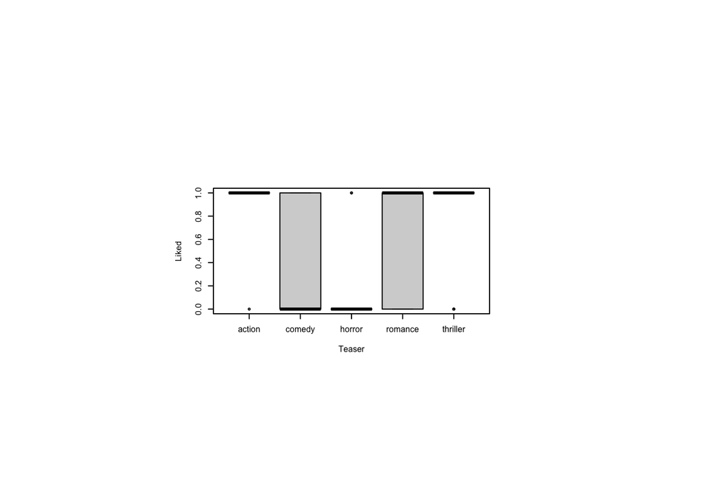

```r
par(pin=c(2.75,1.25),cex=0.5)
boxplot(Liked~Teaser,data=te)
```

Investigate order effects.

```r
contrasts(te$Order) <- "contr.sum"
m <- glmer(Liked ~ Order + (1|Subject), data=te, family=binomial, nAGQ=0)
```

```
boundary (singular) fit: see help('isSingular')
```

```r
Anova(m, type=3)
```

```
Analysis of Deviance Table (Type III Wald chisquare tests)

Response: Liked
             Chisq Df Pr(>Chisq)
(Intercept) 1.0392  1     0.3080
Order       3.9205  4     0.4169
```

Conduct a linear mixed model analysis of variance.

```r
contrasts(te$Teaser) <- "contr.sum"
m <- glmer(Liked ~ Teaser + (1|Subject), data=te, family=binomial, nAGQ=0)
```

```
boundary (singular) fit: see help('isSingular')
```

```r
Anova(m, type=3)
```

```
Analysis of Deviance Table (Type III Wald chisquare tests)

Response: Liked
             Chisq Df Pr(>Chisq)
(Intercept)  1.209  1     0.2715
Teaser      26.695  4  2.291e-05 ***
---
Signif. codes:  0 '***' 0.001 '**' 0.01 '*' 0.05 '.' 0.1 ' ' 1
```

```r
#. pacman::p_load(multcomp)
summary(glht(m, mcp(Teaser="Tukey")),
    test=adjusted(type="holm")) # Tukey means compare all pairs
```

```
     Simultaneous Tests for General Linear Hypotheses

Multiple Comparisons of Means: Tukey Contrasts


Fit: glmer(formula = Liked ~ Teaser + (1 | Subject), data = te, family = binomial,
    nAGQ = 0)

Linear Hypotheses:
                        Estimate Std. Error z value Pr(>|z|)
comedy - action == 0     -3.7917     1.1361  -3.337 0.006763 **
horror - action == 0     -5.1417     1.2681  -4.054 0.000502 ***
romance - action == 0    -2.5390     1.1229  -2.261 0.118786
thriller - action == 0   -1.5581     1.1684  -1.334 0.389097
horror - comedy == 0     -1.3499     0.8909  -1.515 0.389097
romance - comedy == 0     1.2528     0.6682   1.875 0.243191
thriller - comedy == 0    2.2336     0.7420   3.010 0.018279 *
romance - horror == 0     2.6027     0.8740   2.978 0.018279 *
thriller - horror == 0    3.5835     0.9317   3.846 0.001080 **
thriller - romance == 0   0.9808     0.7217   1.359 0.389097
---
Signif. codes:  0 '***' 0.001 '**' 0.01 '*' 0.05 '.' 0.1 ' ' 1
(Adjusted p values reported -- holm method)
```

## Finding number of unique words used in posts by males and females (A generalized linear mixed model)

The file `vocab.csv` describes a study in which 50 posts by males and females were analyzed for the number of unique words used. Load the file and tell the number of participants.

```r
vo<-read_csv("vocab.csv")
vo<-within(vo,Subject<-factor(Subject))
vo<-within(vo,Sex<-factor(Sex))
vo<-within(vo,Order<-factor(Order))
vo<-within(vo,Social<-factor(Social))
tail(vo)
```

```
# A tibble: 6 × 5
  Subject Sex   Social   Order Vocab
  <fct>   <fct> <fct>    <fct> <dbl>
1 29      M     Facebook 3        46
2 29      M     Twitter  1        38
3 29      M     Gplus    2        22
4 30      F     Facebook 3       103
5 30      F     Twitter  2        97
6 30      F     Gplus    1        92
```

Create an interaction plot and see how often the lines cross.

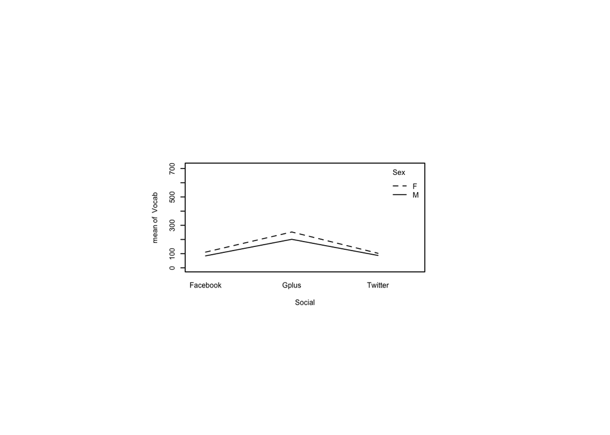

```r
par(pin=c(2.75,1.25),cex=0.5)
with(vo,interaction.plot(Social,Sex,Vocab,ylim=c(0,max(vo$Vocab))))
```

Perform Kolmogorov-Smirnov goodness-of-fit tests on Vocab for each level of Social using exponential distributions.

```r
#. pacman::p_load(MASS)
fit = fitdistr(vo[vo$Social == "Facebook",]$Vocab, "exponential")$estimate
ks.test(vo[vo$Social == "Facebook",]$Vocab, "pexp", rate=fit[1], exact=TRUE)
```

```
    Exact one-sample Kolmogorov-Smirnov test

data:  vo[vo$Social == "Facebook", ]$Vocab
D = 0.17655, p-value = 0.2734
alternative hypothesis: two-sided
```

```r
fit = fitdistr(vo[vo$Social == "Twitter",]$Vocab, "exponential")$estimate
ks.test(vo[vo$Social == "Twitter",]$Vocab, "pexp", rate=fit[1], exact=TRUE)
```

```
    Exact one-sample Kolmogorov-Smirnov test

data:  vo[vo$Social == "Twitter", ]$Vocab
D = 0.099912, p-value = 0.8966
alternative hypothesis: two-sided
```

```r
fit = fitdistr(vo[vo$Social == "Gplus",]$Vocab, "exponential")$estimate
ks.test(vo[vo$Social == "Gplus",]$Vocab, "pexp", rate=fit[1], exact=TRUE)
```

```
    Exact one-sample Kolmogorov-Smirnov test

data:  vo[vo$Social == "Gplus", ]$Vocab
D = 0.14461, p-value = 0.5111
alternative hypothesis: two-sided
```

Use a generallized linear mixed model to conduct a test of order effects on Vocab.

```r
contrasts(vo$Sex) <- "contr.sum"
contrasts(vo$Order) <- "contr.sum"
m <- glmer(Vocab ~ Sex*Order + (1|Subject), data=vo, family=Gamma(link="log"))
Anova(m, type=3)
```

```
Analysis of Deviance Table (Type III Wald chisquare tests)

Response: Vocab
                Chisq Df Pr(>Chisq)
(Intercept) 1179.0809  1     <2e-16 ***
Sex            1.3687  1     0.2420
Order          0.7001  2     0.7047
Sex:Order      2.0655  2     0.3560
---
Signif. codes:  0 '***' 0.001 '**' 0.01 '*' 0.05 '.' 0.1 ' ' 1
```

Conduct a test of Vocab by Sex and Social using a generalized linear mixed model.

```r
contrasts(vo$Sex) <- "contr.sum"
contrasts(vo$Social) <- "contr.sum"
m = glmer(Vocab ~ Sex*Social + (1|Subject), data=vo, family=Gamma(link="log"))
Anova(m, type=3)
```

```
Analysis of Deviance Table (Type III Wald chisquare tests)

Response: Vocab
                Chisq Df Pr(>Chisq)
(Intercept) 1172.6190  1  < 2.2e-16 ***
Sex            0.7925  1     0.3733
Social        26.2078  2  2.037e-06 ***
Sex:Social     0.3471  2     0.8407
---
Signif. codes:  0 '***' 0.001 '**' 0.01 '*' 0.05 '.' 0.1 ' ' 1
```

Perform post hoc pairwise comparisons among levels of Social adjusted with Holm’s sequential Bonferroni procedure.

```r
#. pacman::p_load(multcomp)
summary(glht(m, mcp(Social="Tukey")),
    test=adjusted(type="holm")) # Tukey means compare all pairs
```

```
     Simultaneous Tests for General Linear Hypotheses

Multiple Comparisons of Means: Tukey Contrasts


Fit: glmer(formula = Vocab ~ Sex * Social + (1 | Subject), data = vo,
    family = Gamma(link = "log"))

Linear Hypotheses:
                        Estimate Std. Error z value Pr(>|z|)
Gplus - Facebook == 0     0.8676     0.2092   4.148 6.72e-05 ***
Twitter - Facebook == 0  -0.1127     0.2026  -0.556    0.578
Twitter - Gplus == 0     -0.9803     0.2071  -4.734 6.60e-06 ***
---
Signif. codes:  0 '***' 0.001 '**' 0.01 '*' 0.05 '.' 0.1 ' ' 1
(Adjusted p values reported -- holm method)
```

## Judging search effort among different search engines (Another generalized linear mixed model)

Recode Effort from `websearch3.csv` as an ordinal response.

```r
ws<-within(ws,Effort<-factor(Effort))
ws<-within(ws,Effort<-ordered(Effort))
summary(ws)
```

```
    Subject      Engine   Order     Searches     Effort
 1      : 3   Bing  :30   1:30   Min.   : 92.0   1: 6
 2      : 3   Google:30   2:30   1st Qu.:139.0   2: 8
 3      : 3   Yahoo :30   3:30   Median :161.0   3:19
 4      : 3                      Mean   :161.6   4:16
 5      : 3                      3rd Qu.:181.8   5:16
 6      : 3                      Max.   :236.0   6:15
 (Other):72                                      7:10
```

Conduct an ordinal logistic regression to determine Effort by Engine, using a generalized linear mixed model.

```r
pacman::p_load(ordinal) # provides clmm
#. pacman::p_load(RVAideMemoire) # provides Anova.clmm
ws2<-data.frame(ws)
m<-clmm(Effort~Engine + (1|Subject),data=ws2)
Anova.clmm(m,type=3)
```

```
Analysis of Deviance Table (Type III tests)

Response: Effort
       LR Chisq Df Pr(>Chisq)
Engine    8.102  2     0.0174 *
---
Signif. codes:  0 '***' 0.001 '**' 0.01 '*' 0.05 '.' 0.1 ' ' 1
```

Perform pairwise comparisons of Engine on Effort.

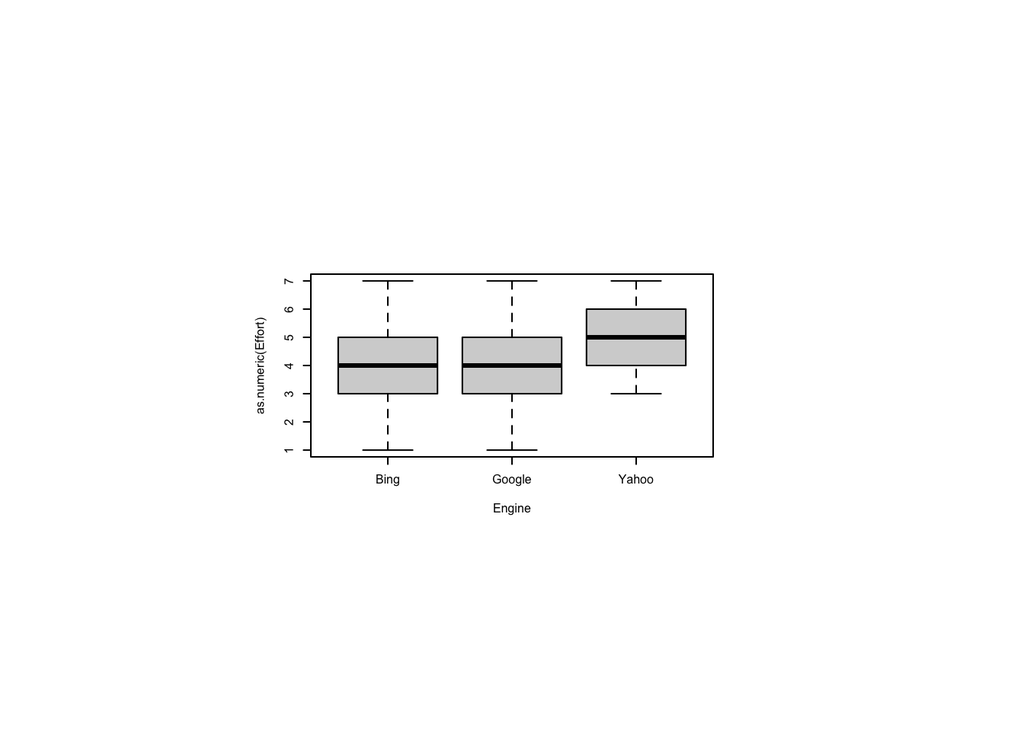

```r
par(pin=c(2.75,1.25),cex=0.5)
plot(as.numeric(Effort) ~ Engine,data=ws2)
```

```r
#. pacman::p_load(lme4)
#. pacman::p_load(multcomp)
m <- lmer(as.numeric(Effort)~Engine + (1|Subject), data=ws2)
```

```
boundary (singular) fit: see help('isSingular')
```

```r
summary(glht(m,mcp(Engine="Tukey")),test=adjusted(type="holm"))
```

```
     Simultaneous Tests for General Linear Hypotheses

Multiple Comparisons of Means: Tukey Contrasts


Fit: lmer(formula = as.numeric(Effort) ~ Engine + (1 | Subject), data = ws2)

Linear Hypotheses:
                    Estimate Std. Error z value Pr(>|z|)
Google - Bing == 0  -0.03333    0.42899  -0.078   0.9381
Yahoo - Bing == 0    1.10000    0.42899   2.564   0.0247 *
Yahoo - Google == 0  1.13333    0.42899   2.642   0.0247 *
---
Signif. codes:  0 '***' 0.001 '**' 0.01 '*' 0.05 '.' 0.1 ' ' 1
(Adjusted p values reported -- holm method)
```